Note: render Rmd from within R, with the environment built from reqs.yaml activated, with:

> rmarkdown::render(‘tutorial-de.Rmd’, output_file = ‘index.html’)

or from the command line:

> Rscript -e “rmarkdown::render(‘tutorial-de.Rmd’, output_file = ‘index.html’)”

# Differential expression with Seurat

This report is based on the Seurat tutorial for differential expression:

https://satijalab.org/seurat/articles/de_vignette

using the publicly available dataset `ifnb` (installed via `InstallData("ifnb")`.

I wanted to compare the differentially expressed genes (DEG) calculated several ways:

- Seurat genes markers from single cell counts, calculated with `FindMarkers`
- Seurat DEG genes from pseudobulk counts, calculated with `FindMarkers` after aggregating the counts with `AggregateExpression`
- manual aggregation of single cell counts to pseudobulk counts, followed by DESeq2 normalization and differential expression analysis.

This was also a personal exercice of using Conda environments and rendering Rmds of single cell data analysis on my tablet (one of those with built-in Linux development environment capabilities). My “other computer” being an HPC system, here I had to be very mindful of ressources.

## Metadata table

The `ifnb` data does not come with the biological replicate metadata info. It can be downloaded from Github, but for the purpose of this tutorial I decided to randomly assign cells to a replicate, for simplicity. At least 3 replicates are required for testing in pseudobulk mode.

After pseudobulking, each ‘cell’ is a condition-rep-celltype pseudobulk profile. Idents is automatically set to orig.ident, which is the pseudobulking group.by combination of columns.

For DE testing, we want the groups without the rep info.

### Original

| de_group | Freq |
| --- | --- |
| B Activated_CTRL | 185 |
| B Activated_STIM | 203 |
| B_CTRL | 407 |
| B_STIM | 571 |
| CD14 Mono_CTRL | 2215 |
| CD14 Mono_STIM | 2147 |
| CD16 Mono_CTRL | 507 |
| CD16 Mono_STIM | 537 |
| CD4 Memory T_CTRL | 859 |
| CD4 Memory T_STIM | 903 |
| CD4 Naive T_CTRL | 978 |
| CD4 Naive T_STIM | 1526 |
| CD8 T_CTRL | 352 |
| CD8 T_STIM | 462 |
| DC_CTRL | 258 |
| DC_STIM | 214 |
| Eryth_CTRL | 23 |
| Eryth_STIM | 32 |
| Mk_CTRL | 115 |
| Mk_STIM | 121 |
| NK_CTRL | 298 |
| NK_STIM | 321 |
| pDC_CTRL | 51 |
| pDC_STIM | 81 |
| T activated_CTRL | 300 |
| T activated_STIM | 333 |

### After adding randomly-attributed replicate metadata

|  | rep1 | rep2 | rep3 |
| --- | --- | --- | --- |
| B Activated_CTRL | 59 | 68 | 58 |
| B Activated_STIM | 68 | 79 | 56 |
| B_CTRL | 137 | 131 | 139 |
| B_STIM | 182 | 194 | 195 |
| CD14 Mono_CTRL | 720 | 752 | 743 |
| CD14 Mono_STIM | 710 | 701 | 736 |
| CD16 Mono_CTRL | 175 | 159 | 173 |
| CD16 Mono_STIM | 186 | 178 | 173 |
| CD4 Memory T_CTRL | 290 | 295 | 274 |
| CD4 Memory T_STIM | 307 | 295 | 301 |
| CD4 Naive T_CTRL | 318 | 330 | 330 |
| CD4 Naive T_STIM | 518 | 508 | 500 |
| CD8 T_CTRL | 113 | 119 | 120 |
| CD8 T_STIM | 159 | 140 | 163 |
| DC_CTRL | 81 | 99 | 78 |
| DC_STIM | 68 | 79 | 67 |
| Eryth_CTRL | 11 | 8 | 4 |
| Eryth_STIM | 8 | 15 | 9 |
| Mk_CTRL | 38 | 42 | 35 |
| Mk_STIM | 46 | 42 | 33 |
| NK_CTRL | 85 | 102 | 111 |
| NK_STIM | 110 | 98 | 113 |
| pDC_CTRL | 19 | 10 | 22 |
| pDC_STIM | 42 | 15 | 24 |
| T activated_CTRL | 102 | 101 | 97 |
| T activated_STIM | 115 | 106 | 112 |

## Perform DE analysis on single cell counts

By default, `FindMarkers` testing is based on the non-parametric Wilcoxon rank sum test. Each cell is considered a different sample. We test each cell type for STIM vs. CTRL. Default `slot` is `data`.

Active assay is RNA.

### CD14 Mono

|  | p_val | avg_log2FC | pct.1 | pct.2 | p_val_adj |
| --- | --- | --- | --- | --- | --- |
| IFIT1 | 0 | 7.319139 | 0.985 | 0.033 | 0 |
| CXCL10 | 0 | 8.036563 | 0.984 | 0.035 | 0 |
| RSAD2 | 0 | 6.741673 | 0.988 | 0.045 | 0 |
| TNFSF10 | 0 | 6.991279 | 0.989 | 0.047 | 0 |
| IFIT3 | 0 | 6.883785 | 0.992 | 0.056 | 0 |
| IFIT2 | 0 | 7.179929 | 0.961 | 0.039 | 0 |
| CXCL11 | 0 | 8.624208 | 0.932 | 0.012 | 0 |
| CCL8 | 0 | 9.134191 | 0.918 | 0.017 | 0 |
| IDO1 | 0 | 5.455898 | 0.965 | 0.089 | 0 |
| MX1 | 0 | 5.059052 | 0.960 | 0.093 | 0 |
| IL1RN | 0 | 6.100382 | 0.899 | 0.039 | 0 |
| TNFSF13B | 0 | 4.845720 | 0.945 | 0.089 | 0 |
| LY6E | 0 | 4.805693 | 0.998 | 0.149 | 0 |
| OAS1 | 0 | 4.073584 | 0.950 | 0.141 | 0 |
| IFITM2 | 0 | 4.281267 | 0.898 | 0.121 | 0 |

### pDC

|  | p_val | avg_log2FC | pct.1 | pct.2 | p_val_adj |
| --- | --- | --- | --- | --- | --- |
| ISG15 | 0 | 5.829713 | 1.000 | 0.216 | 0 |
| MX1 | 0 | 4.473988 | 1.000 | 0.176 | 0 |
| LY6E | 0 | 5.272373 | 0.963 | 0.078 | 0 |
| ISG20 | 0 | 4.028967 | 1.000 | 0.314 | 0 |
| IFI6 | 0 | 5.115461 | 0.975 | 0.078 | 0 |
| IFIT3 | 0 | 6.310964 | 0.951 | 0.059 | 0 |
| TNFSF10 | 0 | 6.361210 | 0.926 | 0.059 | 0 |
| OAS1 | 0 | 5.573479 | 0.926 | 0.059 | 0 |
| IFI35 | 0 | 3.872349 | 0.926 | 0.157 | 0 |
| UBE2L6 | 0 | 3.324502 | 0.951 | 0.235 | 0 |
| IFIT1 | 0 | 6.145160 | 0.840 | 0.039 | 0 |
| IFI44L | 0 | 3.732810 | 0.914 | 0.118 | 0 |
| LAP3 | 0 | 2.912423 | 0.938 | 0.392 | 0 |
| PSMB9 | 0 | 2.552610 | 0.963 | 0.490 | 0 |
| BST2 | 0 | 1.965863 | 0.988 | 0.784 | 0 |

### CD4 Memory T

|  | p_val | avg_log2FC | pct.1 | pct.2 | p_val_adj |
| --- | --- | --- | --- | --- | --- |
| ISG15 | 0 | 4.8434281 | 0.990 | 0.207 | 0 |
| IFI6 | 0 | 5.8020773 | 0.950 | 0.064 | 0 |
| ISG20 | 0 | 3.0613299 | 0.982 | 0.485 | 0 |
| IFIT1 | 0 | 7.3400262 | 0.821 | 0.010 | 0 |
| IFIT3 | 0 | 6.2277021 | 0.819 | 0.016 | 0 |
| LY6E | 0 | 4.2479642 | 0.858 | 0.102 | 0 |
| MX1 | 0 | 4.4438645 | 0.838 | 0.092 | 0 |
| MT2A | 0 | 4.5130615 | 0.721 | 0.066 | 0 |
| B2M | 0 | 0.6090571 | 1.000 | 1.000 | 0 |
| IFIT2 | 0 | 5.5483776 | 0.623 | 0.013 | 0 |
| SAT1 | 0 | 2.7320510 | 0.828 | 0.288 | 0 |
| OAS1 | 0 | 4.3024350 | 0.610 | 0.045 | 0 |
| IFI44L | 0 | 4.1829031 | 0.607 | 0.047 | 0 |
| RSAD2 | 0 | 5.0416701 | 0.523 | 0.012 | 0 |
| PLSCR1 | 0 | 4.5378060 | 0.517 | 0.033 | 0 |

### T activated

|  | p_val | avg_log2FC | pct.1 | pct.2 | p_val_adj |
| --- | --- | --- | --- | --- | --- |
| ISG15 | 0 | 4.107049 | 0.976 | 0.323 | 0 |
| IFIT3 | 0 | 5.584642 | 0.877 | 0.033 | 0 |
| IFIT1 | 0 | 6.029865 | 0.781 | 0.023 | 0 |
| RSAD2 | 0 | 4.724328 | 0.760 | 0.017 | 0 |
| IFI6 | 0 | 5.433104 | 0.766 | 0.037 | 0 |
| IFIT2 | 0 | 4.996499 | 0.754 | 0.030 | 0 |
| LY6E | 0 | 4.568766 | 0.769 | 0.080 | 0 |
| MX1 | 0 | 4.010256 | 0.751 | 0.093 | 0 |
| OAS1 | 0 | 4.819688 | 0.670 | 0.040 | 0 |
| ISG20 | 0 | 2.762390 | 0.850 | 0.333 | 0 |
| PLSCR1 | 0 | 4.948594 | 0.631 | 0.037 | 0 |
| IFI44L | 0 | 5.061007 | 0.622 | 0.033 | 0 |
| IRF7 | 0 | 3.158831 | 0.745 | 0.150 | 0 |
| GBP1 | 0 | 4.278940 | 0.637 | 0.060 | 0 |
| EIF2AK2 | 0 | 3.922325 | 0.625 | 0.060 | 0 |

### CD4 Naive T

|  | p_val | avg_log2FC | pct.1 | pct.2 | p_val_adj |
| --- | --- | --- | --- | --- | --- |
| IFIT3 | 0 | 7.2124244 | 0.893 | 0.006 | 0 |
| IFI6 | 0 | 5.4637641 | 0.938 | 0.065 | 0 |
| ISG15 | 0 | 4.8046176 | 0.993 | 0.167 | 0 |
| ISG20 | 0 | 2.8760899 | 0.976 | 0.459 | 0 |
| IFIT1 | 0 | 6.6790010 | 0.844 | 0.015 | 0 |
| LY6E | 0 | 3.7562475 | 0.893 | 0.148 | 0 |
| MX1 | 0 | 4.7097979 | 0.812 | 0.069 | 0 |
| B2M | 0 | 0.5671462 | 1.000 | 1.000 | 0 |
| IFIT2 | 0 | 6.0286696 | 0.622 | 0.011 | 0 |
| OAS1 | 0 | 5.8122678 | 0.609 | 0.018 | 0 |
| IFI44L | 0 | 5.1263445 | 0.603 | 0.025 | 0 |
| RSAD2 | 0 | 7.2039563 | 0.550 | 0.006 | 0 |
| TNFSF10 | 0 | 5.0409892 | 0.583 | 0.036 | 0 |
| MT2A | 0 | 3.9699064 | 0.610 | 0.063 | 0 |
| IRF7 | 0 | 3.5151829 | 0.604 | 0.071 | 0 |

### CD8 T

|  | p_val | avg_log2FC | pct.1 | pct.2 | p_val_adj |
| --- | --- | --- | --- | --- | --- |
| IFI6 | 0 | 5.0940255 | 0.955 | 0.099 | 0 |
| ISG15 | 0 | 4.1828463 | 0.989 | 0.301 | 0 |
| ISG20 | 0 | 3.0978933 | 0.991 | 0.480 | 0 |
| IFIT1 | 0 | 5.1363058 | 0.877 | 0.040 | 0 |
| LY6E | 0 | 3.5846546 | 0.883 | 0.159 | 0 |
| MX1 | 0 | 4.9149365 | 0.816 | 0.065 | 0 |
| IFIT3 | 0 | 4.9213308 | 0.781 | 0.034 | 0 |
| MT2A | 0 | 4.4437999 | 0.697 | 0.071 | 0 |
| OAS1 | 0 | 5.1113771 | 0.649 | 0.034 | 0 |
| PLSCR1 | 0 | 4.5491292 | 0.623 | 0.051 | 0 |
| B2M | 0 | 0.5411335 | 1.000 | 1.000 | 0 |
| IFIT2 | 0 | 5.0082722 | 0.543 | 0.026 | 0 |
| LAG3 | 0 | 3.9957573 | 0.595 | 0.071 | 0 |
| RSAD2 | 0 | 4.9106864 | 0.506 | 0.009 | 0 |
| IRF7 | 0 | 2.7259800 | 0.645 | 0.145 | 0 |

### Mk

|  | p_val | avg_log2FC | pct.1 | pct.2 | p_val_adj |
| --- | --- | --- | --- | --- | --- |
| ISG15 | 0 | 4.843583 | 0.975 | 0.261 | 0 |
| ISG20 | 0 | 3.286477 | 0.983 | 0.391 | 0 |
| IFIT1 | 0 | 6.369095 | 0.843 | 0.026 | 0 |
| IFIT3 | 0 | 6.029154 | 0.851 | 0.061 | 0 |
| IFI6 | 0 | 4.342005 | 0.876 | 0.200 | 0 |
| LY6E | 0 | 3.907988 | 0.884 | 0.139 | 0 |
| MX1 | 0 | 4.636167 | 0.835 | 0.078 | 0 |
| IFIT2 | 0 | 7.610672 | 0.661 | 0.009 | 0 |
| EPSTI1 | 0 | 4.484555 | 0.587 | 0.070 | 0 |
| IRF7 | 0 | 3.120535 | 0.645 | 0.130 | 0 |
| RSAD2 | 0 | 6.583860 | 0.521 | 0.026 | 0 |
| IFI44L | 0 | 3.807066 | 0.587 | 0.061 | 0 |
| OASL | 0 | 4.177920 | 0.562 | 0.052 | 0 |
| OAS1 | 0 | 3.053311 | 0.661 | 0.165 | 0 |
| MT2A | 0 | 3.662764 | 0.595 | 0.104 | 0 |

### B Activated

|  | p_val | avg_log2FC | pct.1 | pct.2 | p_val_adj |
| --- | --- | --- | --- | --- | --- |
| ISG15 | 0 | 5.6257511 | 1.000 | 0.189 | 0 |
| ISG20 | 0 | 3.7982033 | 1.000 | 0.486 | 0 |
| IFIT3 | 0 | 11.9208358 | 0.857 | 0.000 | 0 |
| IFI6 | 0 | 6.3160103 | 0.842 | 0.032 | 0 |
| MX1 | 0 | 6.1187189 | 0.803 | 0.038 | 0 |
| PLSCR1 | 0 | 4.9707004 | 0.759 | 0.054 | 0 |
| IRF7 | 0 | 4.5106588 | 0.778 | 0.086 | 0 |
| LY6E | 0 | 3.9624094 | 0.768 | 0.141 | 0 |
| IFIT1 | 0 | 10.8434400 | 0.626 | 0.000 | 0 |
| CXCL10 | 0 | 9.8881109 | 0.606 | 0.005 | 0 |
| EPSTI1 | 0 | 4.7245802 | 0.650 | 0.043 | 0 |
| B2M | 0 | 0.5741454 | 1.000 | 1.000 | 0 |
| GBP1 | 0 | 4.7693760 | 0.645 | 0.054 | 0 |
| UBE2L6 | 0 | 2.4010441 | 0.828 | 0.254 | 0 |
| IFI44L | 0 | 5.0810414 | 0.571 | 0.027 | 0 |

### B

|  | p_val | avg_log2FC | pct.1 | pct.2 | p_val_adj |
| --- | --- | --- | --- | --- | --- |
| ISG15 | 0 | 5.0588481 | 0.998 | 0.233 | 0 |
| IFIT3 | 0 | 6.1124940 | 0.965 | 0.052 | 0 |
| IFI6 | 0 | 5.4933132 | 0.965 | 0.076 | 0 |
| ISG20 | 0 | 3.0549593 | 1.000 | 0.668 | 0 |
| IFIT1 | 0 | 6.2320388 | 0.907 | 0.029 | 0 |
| MX1 | 0 | 3.9798482 | 0.905 | 0.115 | 0 |
| LY6E | 0 | 3.7907800 | 0.898 | 0.150 | 0 |
| TNFSF10 | 0 | 6.5802175 | 0.786 | 0.020 | 0 |
| IFIT2 | 0 | 5.5525558 | 0.786 | 0.037 | 0 |
| B2M | 0 | 0.6104044 | 1.000 | 1.000 | 0 |
| PLSCR1 | 0 | 3.8010721 | 0.793 | 0.113 | 0 |
| IRF7 | 0 | 3.1992949 | 0.835 | 0.187 | 0 |
| CXCL10 | 0 | 8.0906108 | 0.651 | 0.010 | 0 |
| UBE2L6 | 0 | 2.5167981 | 0.851 | 0.297 | 0 |
| PSMB9 | 0 | 1.7715351 | 0.937 | 0.568 | 0 |

### DC

|  | p_val | avg_log2FC | pct.1 | pct.2 | p_val_adj |
| --- | --- | --- | --- | --- | --- |
| IFIT3 | 0 | 8.833866 | 0.991 | 0.023 | 0 |
| IFIT1 | 0 | 9.549194 | 0.981 | 0.012 | 0 |
| IFIT2 | 0 | 9.093149 | 0.981 | 0.012 | 0 |
| TNFSF10 | 0 | 9.172346 | 0.981 | 0.019 | 0 |
| CXCL10 | 0 | 9.382425 | 0.977 | 0.012 | 0 |
| RSAD2 | 0 | 7.599587 | 0.986 | 0.027 | 0 |
| MX1 | 0 | 5.869923 | 1.000 | 0.093 | 0 |
| CXCL11 | 0 | 8.931608 | 0.963 | 0.008 | 0 |
| LY6E | 0 | 5.243449 | 0.995 | 0.136 | 0 |
| IFITM3 | 0 | 5.754103 | 1.000 | 0.174 | 0 |
| APOBEC3A | 0 | 7.377986 | 0.958 | 0.039 | 0 |
| OAS1 | 0 | 5.460449 | 0.977 | 0.097 | 0 |
| IFI6 | 0 | 4.776552 | 1.000 | 0.194 | 0 |
| ISG15 | 0 | 6.662182 | 1.000 | 0.353 | 0 |
| OASL | 0 | 6.543619 | 0.921 | 0.023 | 0 |

### CD16 Mono

|  | p_val | avg_log2FC | pct.1 | pct.2 | p_val_adj |
| --- | --- | --- | --- | --- | --- |
| IFIT1 | 0 | 5.848003 | 1.000 | 0.097 | 0 |
| ISG15 | 0 | 5.353134 | 1.000 | 0.495 | 0 |
| IFIT3 | 0 | 4.432872 | 0.993 | 0.316 | 0 |
| ISG20 | 0 | 4.097362 | 1.000 | 0.456 | 0 |
| IFITM3 | 0 | 3.184614 | 1.000 | 0.645 | 0 |
| RSAD2 | 0 | 5.151597 | 0.955 | 0.079 | 0 |
| IFIT2 | 0 | 4.634380 | 0.974 | 0.170 | 0 |
| IFI6 | 0 | 3.414658 | 0.998 | 0.377 | 0 |
| LY6E | 0 | 3.298778 | 1.000 | 0.418 | 0 |
| TNFSF10 | 0 | 3.366590 | 1.000 | 0.491 | 0 |
| MX1 | 0 | 4.031346 | 0.976 | 0.168 | 0 |
| APOBEC3A | 0 | 3.750112 | 0.996 | 0.398 | 0 |
| CXCL10 | 0 | 4.575718 | 0.985 | 0.276 | 0 |
| OASL | 0 | 4.017008 | 0.957 | 0.185 | 0 |
| IRF7 | 0 | 2.984086 | 0.980 | 0.464 | 0 |

### NK

|  | p_val | avg_log2FC | pct.1 | pct.2 | p_val_adj |
| --- | --- | --- | --- | --- | --- |
| IFI6 | 0 | 5.237586 | 0.972 | 0.094 | 0 |
| ISG15 | 0 | 4.575879 | 0.988 | 0.315 | 0 |
| ISG20 | 0 | 3.375592 | 0.991 | 0.456 | 0 |
| IFIT1 | 0 | 6.018677 | 0.866 | 0.037 | 0 |
| IFIT3 | 0 | 6.240995 | 0.847 | 0.040 | 0 |
| MX1 | 0 | 3.942139 | 0.891 | 0.121 | 0 |
| LY6E | 0 | 2.446112 | 0.950 | 0.362 | 0 |
| PLSCR1 | 0 | 3.470852 | 0.788 | 0.141 | 0 |
| IFITM3 | 0 | 4.022746 | 0.745 | 0.114 | 0 |
| TNFSF10 | 0 | 3.421115 | 0.766 | 0.161 | 0 |
| OAS1 | 0 | 3.675542 | 0.685 | 0.074 | 0 |
| IFI44L | 0 | 3.550353 | 0.688 | 0.077 | 0 |
| IRF7 | 0 | 2.646435 | 0.791 | 0.218 | 0 |
| IFIT2 | 0 | 4.646627 | 0.614 | 0.040 | 0 |
| BST2 | 0 | 2.024020 | 0.857 | 0.346 | 0 |

### Eryth

|  | p_val | avg_log2FC | pct.1 | pct.2 | p_val_adj |
| --- | --- | --- | --- | --- | --- |
| IFIT1 | 0.00e+00 | 5.5792636 | 1.000 | 0.043 | 0.0000026 |
| ISG15 | 0.00e+00 | 7.0705796 | 1.000 | 0.174 | 0.0000047 |
| ISG20 | 0.00e+00 | 3.5551657 | 1.000 | 0.435 | 0.0000414 |
| IFI6 | 0.00e+00 | 5.8056174 | 0.906 | 0.087 | 0.0000642 |
| MX1 | 0.00e+00 | 6.2621626 | 0.875 | 0.043 | 0.0001153 |
| IFIT3 | 1.00e-07 | 5.0343432 | 0.844 | 0.130 | 0.0012331 |
| LY6E | 1.00e-07 | 4.5684565 | 0.844 | 0.130 | 0.0018280 |
| IFIT2 | 2.00e-07 | 7.7176455 | 0.750 | 0.000 | 0.0029891 |
| TNFSF10 | 1.80e-06 | 4.1212692 | 0.812 | 0.174 | 0.0250230 |
| HERC5 | 2.00e-06 | 4.5331101 | 0.719 | 0.043 | 0.0279194 |
| OASL | 3.20e-06 | 4.0268729 | 0.719 | 0.043 | 0.0443040 |
| IRF7 | 5.00e-06 | 3.1601783 | 0.812 | 0.261 | 0.0706950 |
| TMSB10 | 1.01e-05 | 1.9479044 | 0.969 | 0.739 | 0.1417716 |
| GBP1 | 1.36e-05 | 3.4400612 | 0.719 | 0.130 | 0.1917637 |
| B2M | 2.88e-05 | 0.8799891 | 1.000 | 1.000 | 0.4049104 |

## Perform DE analysis after pseudobulking

To pseudobulk, we use `AggregateExpression()` to sum together gene counts of all the cells from the same sample for each cell type. This results in one gene expression profile per sample and cell type. We can then perform DE analysis using DESeq2 on the sample level. This treats the samples, rather than the individual cells, as independent observations.

We can perform DE testing on the pseudobulk level with `FindMarkers`, with the parameters `test.use="DESeq2", group.by="de_group"` where `de_group` defines the pseudobulk samples. Since `test.use` is set to `DESeq2`, `slot` is automatically set to `counts`.

Active assay is RNA.

### CD14 Mono

|  | p_val | avg_log2FC | pct.1 | pct.2 | p_val_adj |
| --- | --- | --- | --- | --- | --- |
| ISG15 | 0 | 6.524350 | 1 | 1 | 0 |
| IFI6 | 0 | 3.627686 | 1 | 1 | 0 |
| GBP1 | 0 | 2.582693 | 1 | 1 | 0 |
| MNDA | 0 | 2.707099 | 1 | 1 | 0 |
| TMSB10 | 0 | 1.704938 | 1 | 1 | 0 |
| VAMP5 | 0 | 3.070410 | 1 | 1 | 0 |
| SSB | 0 | 2.631551 | 1 | 1 | 0 |
| PLSCR1 | 0 | 2.449718 | 1 | 1 | 0 |
| LAP3 | 0 | 2.081515 | 1 | 1 | 0 |
| CXCL11 | 0 | 6.446433 | 1 | 1 | 0 |
| HSPA1A | 0 | 2.719810 | 1 | 1 | 0 |
| PSMB9 | 0 | 1.770025 | 1 | 1 | 0 |
| FAM26F | 0 | 4.044696 | 1 | 1 | 0 |
| DYNLT1 | 0 | 2.208957 | 1 | 1 | 0 |
| HSPB1 | 0 | 2.390378 | 1 | 1 | 0 |

### CD4 Naive T

|  | p_val | avg_log2FC | pct.1 | pct.2 | p_val_adj |
| --- | --- | --- | --- | --- | --- |
| B2M | 0 | 0.5759136 | 1 | 1 | 0 |
| IFI6 | 0 | 4.8328469 | 1 | 1 | 0 |
| LY6E | 0 | 3.4166479 | 1 | 1 | 0 |
| MX1 | 0 | 4.1221295 | 1 | 1 | 0 |
| HLA-B | 0 | 0.6101486 | 1 | 1 | 0 |
| PSME2 | 0 | 1.8197431 | 1 | 1 | 0 |
| TMSB10 | 0 | 0.9899916 | 1 | 1 | 0 |
| ISG15 | 0 | 4.6615910 | 1 | 1 | 0 |
| ISG20 | 0 | 2.8152841 | 1 | 1 | 0 |
| MT2A | 0 | 3.3402902 | 1 | 1 | 0 |
| TNFSF10 | 0 | 3.9363520 | 1 | 1 | 0 |
| UBE2L6 | 0 | 2.3113574 | 1 | 1 | 0 |
| IFIT1 | 0 | 5.1346985 | 1 | 1 | 0 |
| IRF7 | 0 | 2.9697877 | 1 | 1 | 0 |
| SAT1 | 0 | 2.0467662 | 1 | 1 | 0 |

### CD4 Memory T

|  | p_val | avg_log2FC | pct.1 | pct.2 | p_val_adj |
| --- | --- | --- | --- | --- | --- |
| ISG20 | 0 | 2.9848144 | 1 | 1 | 0 |
| B2M | 0 | 0.6143407 | 1 | 1 | 0 |
| IFI6 | 0 | 5.1055440 | 1 | 1 | 0 |
| SAT1 | 0 | 2.6401980 | 1 | 1 | 0 |
| LY6E | 0 | 3.8320128 | 1 | 1 | 0 |
| MX1 | 0 | 3.9459894 | 1 | 1 | 0 |
| MT2A | 0 | 3.8241441 | 1 | 1 | 0 |
| TMSB10 | 0 | 1.4218761 | 1 | 1 | 0 |
| TNFSF10 | 0 | 3.4347907 | 1 | 1 | 0 |
| MYL12A | 0 | 1.4089880 | 1 | 1 | 0 |
| HLA-B | 0 | 0.5370884 | 1 | 1 | 0 |
| IFI44L | 0 | 3.4440966 | 1 | 1 | 0 |
| OAS1 | 0 | 3.4457488 | 1 | 1 | 0 |
| IFIT1 | 0 | 5.1339770 | 1 | 1 | 0 |
| UBE2L6 | 0 | 2.2689361 | 1 | 1 | 0 |

### CD16 Mono

|  | p_val | avg_log2FC | pct.1 | pct.2 | p_val_adj |
| --- | --- | --- | --- | --- | --- |
| ISG15 | 0 | 5.405094 | 1 | 1 | 0 |
| TNFSF10 | 0 | 3.349774 | 1 | 1 | 0 |
| LY6E | 0 | 3.215820 | 1 | 1 | 0 |
| IFIT3 | 0 | 4.270443 | 1 | 1 | 0 |
| IFIT1 | 0 | 5.512975 | 1 | 1 | 0 |
| IFITM3 | 0 | 3.148605 | 1 | 1 | 0 |
| ISG20 | 0 | 4.032926 | 1 | 1 | 0 |
| IFI6 | 0 | 3.300614 | 1 | 1 | 0 |
| IFIT2 | 0 | 4.298292 | 1 | 1 | 0 |
| MX1 | 0 | 3.768779 | 1 | 1 | 0 |
| IRF7 | 0 | 2.862734 | 1 | 1 | 0 |
| MT2A | 0 | 2.702728 | 1 | 1 | 0 |
| TMSB10 | 0 | 1.439850 | 1 | 1 | 0 |
| RSAD2 | 0 | 4.527391 | 1 | 1 | 0 |
| OASL | 0 | 3.646063 | 1 | 1 | 0 |

### B

|  | p_val | avg_log2FC | pct.1 | pct.2 | p_val_adj |
| --- | --- | --- | --- | --- | --- |
| ISG15 | 0 | 4.9194353 | 1 | 1 | 0 |
| B2M | 0 | 0.5883803 | 1 | 1 | 0 |
| ISG20 | 0 | 3.0284044 | 1 | 1 | 0 |
| IFI6 | 0 | 4.9658801 | 1 | 1 | 0 |
| MX1 | 0 | 3.7372670 | 1 | 1 | 0 |
| LY6E | 0 | 3.5054247 | 1 | 1 | 0 |
| IFIT3 | 0 | 5.2825249 | 1 | 1 | 0 |
| IRF7 | 0 | 2.9632413 | 1 | 1 | 0 |
| IFIT1 | 0 | 5.1102165 | 1 | 1 | 0 |
| UBE2L6 | 0 | 2.3811484 | 1 | 1 | 0 |
| PLSCR1 | 0 | 3.3946976 | 1 | 1 | 0 |
| PSMB9 | 0 | 1.6589015 | 1 | 1 | 0 |
| SAT1 | 0 | 1.9285009 | 1 | 1 | 0 |
| CXCL10 | 0 | 6.4074200 | 1 | 1 | 0 |
| IFITM2 | 0 | 2.7793557 | 1 | 1 | 0 |

### CD8 T

|  | p_val | avg_log2FC | pct.1 | pct.2 | p_val_adj |
| --- | --- | --- | --- | --- | --- |
| ISG15 | 0 | 4.242469 | 1 | 1 | 0 |
| IFI6 | 0 | 4.729437 | 1 | 1 | 0 |
| LY6E | 0 | 3.381996 | 1 | 1 | 0 |
| IFIT3 | 0 | 4.478730 | 1 | 1 | 0 |
| MX1 | 0 | 4.350148 | 1 | 1 | 0 |
| IFIT1 | 0 | 4.543016 | 1 | 1 | 0 |
| ISG20 | 0 | 3.026794 | 1 | 1 | 0 |
| MT2A | 0 | 3.783692 | 1 | 1 | 0 |
| LAG3 | 0 | 3.255785 | 1 | 1 | 0 |
| OAS1 | 0 | 4.058428 | 1 | 1 | 0 |
| PLSCR1 | 0 | 3.647765 | 1 | 1 | 0 |
| TMSB10 | 0 | 1.099068 | 1 | 1 | 0 |
| OASL | 0 | 1.711739 | 1 | 1 | 0 |
| IRF7 | 0 | 2.465489 | 1 | 1 | 0 |
| UBE2L6 | 0 | 2.124143 | 1 | 1 | 0 |

### T activated

|  | p_val | avg_log2FC | pct.1 | pct.2 | p_val_adj |
| --- | --- | --- | --- | --- | --- |
| ISG15 | 0 | 3.9914526 | 1 | 1 | 0 |
| SAT1 | 0 | 2.3353160 | 1 | 1 | 0 |
| ISG20 | 0 | 2.6977783 | 1 | 1 | 0 |
| MX1 | 0 | 3.6373826 | 1 | 1 | 0 |
| LY6E | 0 | 3.9635196 | 1 | 1 | 0 |
| IFIT1 | 0 | 4.8467127 | 1 | 1 | 0 |
| IFI6 | 0 | 4.6107505 | 1 | 1 | 0 |
| IRF7 | 0 | 2.9306905 | 1 | 1 | 0 |
| B2M | 0 | 0.4460696 | 1 | 1 | 0 |
| OASL | 0 | 3.0265213 | 1 | 1 | 0 |
| UBE2L6 | 0 | 2.5046723 | 1 | 1 | 0 |
| IFI16 | 0 | 2.5705288 | 1 | 1 | 0 |
| GBP1 | 0 | 3.6453435 | 1 | 1 | 0 |
| PLSCR1 | 0 | 4.0545856 | 1 | 1 | 0 |
| EPSTI1 | 0 | 3.0088461 | 1 | 1 | 0 |

### NK

|  | p_val | avg_log2FC | pct.1 | pct.2 | p_val_adj |
| --- | --- | --- | --- | --- | --- |
| ISG20 | 0 | 3.3701773 | 1 | 1 | 0 |
| IFI6 | 0 | 4.8678789 | 1 | 1 | 0 |
| LY6E | 0 | 2.4205232 | 1 | 1 | 0 |
| IFITM3 | 0 | 3.7105438 | 1 | 1 | 0 |
| MX1 | 0 | 3.7176732 | 1 | 1 | 0 |
| IFIT3 | 0 | 5.2462826 | 1 | 1 | 0 |
| PRF1 | 0 | 2.2215166 | 1 | 1 | 0 |
| PLSCR1 | 0 | 3.1964090 | 1 | 1 | 0 |
| TNFSF10 | 0 | 3.1129544 | 1 | 1 | 0 |
| IFIT1 | 0 | 4.9885588 | 1 | 1 | 0 |
| IRF7 | 0 | 2.5039363 | 1 | 1 | 0 |
| B2M | 0 | 0.4268149 | 1 | 1 | 0 |
| OAS1 | 0 | 3.3055314 | 1 | 1 | 0 |
| IFI44L | 0 | 3.1129419 | 1 | 1 | 0 |
| BST2 | 0 | 1.9609531 | 1 | 1 | 0 |

### DC

|  | p_val | avg_log2FC | pct.1 | pct.2 | p_val_adj |
| --- | --- | --- | --- | --- | --- |
| ISG20 | 0 | 3.864821 | 1 | 1 | 0 |
| IFITM3 | 0 | 5.235863 | 1 | 1 | 0 |
| LY6E | 0 | 4.678636 | 1 | 1 | 0 |
| IFI6 | 0 | 4.377627 | 1 | 1 | 0 |
| HSPA1A | 0 | 3.768050 | 1 | 1 | 0 |
| MX1 | 0 | 4.976081 | 1 | 1 | 0 |
| APOBEC3A | 0 | 5.981163 | 1 | 1 | 0 |
| IRF7 | 0 | 3.436853 | 1 | 1 | 0 |
| PLSCR1 | 0 | 2.925921 | 1 | 1 | 0 |
| BST2 | 0 | 2.624977 | 1 | 1 | 0 |
| GBP1 | 0 | 3.801736 | 1 | 1 | 0 |
| OAS1 | 0 | 4.518331 | 1 | 1 | 0 |
| RSAD2 | 0 | 5.994259 | 1 | 1 | 0 |
| LAP3 | 0 | 2.983329 | 1 | 1 | 0 |
| HSPB1 | 0 | 2.712754 | 1 | 1 | 0 |

### B Activated

|  | p_val | avg_log2FC | pct.1 | pct.2 | p_val_adj |
| --- | --- | --- | --- | --- | --- |
| ISG20 | 0 | 3.6223874 | 1 | 1.000 | 0 |
| ISG15 | 0 | 5.2369062 | 1 | 1.000 | 0 |
| LY6E | 0 | 3.4169657 | 1 | 1.000 | 0 |
| B2M | 0 | 0.5571916 | 1 | 1.000 | 0 |
| IRF7 | 0 | 3.7562498 | 1 | 1.000 | 0 |
| MX1 | 0 | 4.8367770 | 1 | 1.000 | 0 |
| IFI6 | 0 | 4.9375013 | 1 | 1.000 | 0 |
| SAT1 | 0 | 1.7894332 | 1 | 1.000 | 0 |
| PLSCR1 | 0 | 4.0903053 | 1 | 1.000 | 0 |
| PSMB9 | 0 | 1.6927915 | 1 | 1.000 | 0 |
| GBP1 | 0 | 3.6329721 | 1 | 0.667 | 0 |
| GBP2 | 0 | 1.8600320 | 1 | 1.000 | 0 |
| BST2 | 0 | 2.1188996 | 1 | 1.000 | 0 |
| EPSTI1 | 0 | 3.7878248 | 1 | 1.000 | 0 |
| CXCL10 | 0 | 7.1741922 | 1 | 0.333 | 0 |

### Mk

|  | p_val | avg_log2FC | pct.1 | pct.2 | p_val_adj |
| --- | --- | --- | --- | --- | --- |
| ISG20 | 0 | 3.495296 | 1 | 1.000 | 0 |
| IFI6 | 0 | 3.816022 | 1 | 1.000 | 0 |
| LY6E | 0 | 3.580342 | 1 | 1.000 | 0 |
| ISG15 | 0 | 5.039666 | 1 | 1.000 | 0 |
| IFIT3 | 0 | 5.110226 | 1 | 1.000 | 0 |
| APOBEC3A | 0 | 3.317737 | 1 | 1.000 | 0 |
| MX1 | 0 | 3.883662 | 1 | 1.000 | 0 |
| TNFSF10 | 0 | 4.367715 | 1 | 1.000 | 0 |
| FTH1 | 0 | -1.399189 | 1 | 1.000 | 0 |
| SAT1 | 0 | 1.584759 | 1 | 1.000 | 0 |
| CCL8 | 0 | 6.653979 | 1 | 0.000 | 0 |
| FTL | 0 | -1.234206 | 1 | 1.000 | 0 |
| IFIT1 | 0 | 5.521378 | 1 | 0.667 | 0 |
| TIMP1 | 0 | -1.497004 | 1 | 1.000 | 0 |
| IFITM3 | 0 | 2.739825 | 1 | 1.000 | 0 |

### pDC

|  | p_val | avg_log2FC | pct.1 | pct.2 | p_val_adj |
| --- | --- | --- | --- | --- | --- |
| ISG15 | 0 | 5.5579099 | 1 | 1.000 | 0 |
| IRF7 | 0 | 2.9650990 | 1 | 1.000 | 0 |
| IFI6 | 0 | 4.7113809 | 1 | 0.667 | 0 |
| LY6E | 0 | 4.5764555 | 1 | 0.667 | 0 |
| BST2 | 0 | 1.9673073 | 1 | 1.000 | 0 |
| IFIT3 | 0 | 5.1640677 | 1 | 0.667 | 0 |
| UBE2L6 | 0 | 3.0946036 | 1 | 1.000 | 0 |
| B2M | 0 | 0.8070993 | 1 | 1.000 | 0 |
| CXCL10 | 0 | 5.9372787 | 1 | 0.333 | 0 |
| PSMB9 | 0 | 2.3867041 | 1 | 1.000 | 0 |
| LAP3 | 0 | 2.6704787 | 1 | 1.000 | 0 |
| IFI44L | 0 | 3.1844365 | 1 | 1.000 | 0 |
| OAS1 | 0 | 4.4865678 | 1 | 0.667 | 0 |
| TNFSF10 | 0 | 4.9950107 | 1 | 0.667 | 0 |
| IFI35 | 0 | 3.2540717 | 1 | 1.000 | 0 |

### Eryth

|  | p_val | avg_log2FC | pct.1 | pct.2 | p_val_adj |
| --- | --- | --- | --- | --- | --- |
| CXCL10 | 0.0e+00 | 7.193009 | 1 | 0.000 | 0.0000000 |
| ISG15 | 0.0e+00 | 6.490707 | 1 | 0.667 | 0.0000000 |
| ISG20 | 0.0e+00 | 3.640179 | 1 | 0.667 | 0.0000000 |
| IFIT3 | 0.0e+00 | 4.102893 | 1 | 0.667 | 0.0000213 |
| CCL8 | 0.0e+00 | 6.127280 | 1 | 0.000 | 0.0000498 |
| TNFSF10 | 0.0e+00 | 3.488526 | 1 | 1.000 | 0.0000760 |
| IFIT1 | 0.0e+00 | 4.313929 | 1 | 0.333 | 0.0004539 |
| IFIT2 | 0.0e+00 | 4.689523 | 1 | 0.000 | 0.0005282 |
| LY6E | 1.0e-07 | 3.917862 | 1 | 0.667 | 0.0015448 |
| IFI6 | 1.0e-07 | 4.503207 | 1 | 0.667 | 0.0017649 |
| RSAD2 | 1.0e-07 | 4.442508 | 1 | 0.000 | 0.0018944 |
| APOBEC3A | 2.0e-07 | 4.817952 | 1 | 0.333 | 0.0024807 |
| MX1 | 1.9e-06 | 4.258549 | 1 | 0.333 | 0.0266099 |
| IDO1 | 2.3e-06 | 3.931627 | 1 | 0.000 | 0.0328132 |
| TMSB10 | 3.0e-06 | 1.945602 | 1 | 1.000 | 0.0417674 |

## Manual pseudobulking and DESeq2 analysis

For comparison purpose, here we do a “quick and dirty” aggregation of counts by replicate to generate pseudobulk counts.

### CD14 Mono

|  | baseMean | log2FoldChange | lfcSE | stat | pvalue | padj |
| --- | --- | --- | --- | --- | --- | --- |
| IFIT2 | 172.84072 | 7.861982 | 0.1840059 | 42.52932 | 0 | 0 |
| IFIT1 | 263.65419 | 7.838845 | 0.1394853 | 55.94016 | 0 | 0 |
| TNFSF10 | 257.25458 | 7.620842 | 0.1813963 | 41.90050 | 0 | 0 |
| IFIT3 | 309.40251 | 7.399593 | 0.1080920 | 68.24024 | 0 | 0 |
| IDO1 | 128.86567 | 5.941060 | 0.1337630 | 44.39388 | 0 | 0 |
| ISG20 | 636.74251 | 5.841943 | 0.1085359 | 53.80949 | 0 | 0 |
| MX1 | 198.10688 | 5.643502 | 0.0873087 | 64.51768 | 0 | 0 |
| MT2A | 96.76234 | 5.575020 | 0.1416471 | 39.26097 | 0 | 0 |
| TNFSF13B | 76.40169 | 5.431631 | 0.1119429 | 48.45697 | 0 | 0 |
| LY6E | 261.48749 | 5.273206 | 0.0689292 | 76.45703 | 0 | 0 |
| MX2 | 46.75834 | 4.755403 | 0.1204715 | 39.35825 | 0 | 0 |
| IFITM2 | 116.60417 | 4.701933 | 0.1211843 | 38.76215 | 0 | 0 |
| OAS1 | 127.30352 | 4.617684 | 0.0799027 | 57.75294 | 0 | 0 |
| OASL | 95.91076 | 4.360401 | 0.0828292 | 52.59756 | 0 | 0 |
| IFI6 | 286.93014 | 4.323800 | 0.0547630 | 78.93337 | 0 | 0 |

### pDC

|  | baseMean | log2FoldChange | lfcSE | stat | pvalue | padj |
| --- | --- | --- | --- | --- | --- | --- |
| APOBEC3B | 135.10719 | 2.678315 | 1.2899384 | 16.411249 | 0 | 0 |
| ISG20 | 636.74251 | 3.934095 | 0.2436925 | 15.988169 | 0 | 0 |
| IRF7 | 169.60347 | 3.193751 | 0.1993265 | 15.941507 | 0 | 0 |
| ISG15 | 2007.80909 | 5.750771 | 0.3785665 | 14.957542 | 0 | 0 |
| B2M | 6936.89506 | 0.943128 | 0.0638609 | 14.768705 | 0 | 0 |
| MX1 | 198.10688 | 4.421756 | 0.3427711 | 12.555048 | 0 | 0 |
| BST2 | 156.00165 | 2.072990 | 0.1656865 | 12.471337 | 0 | 0 |
| IFI6 | 286.93014 | 5.048545 | 0.4280139 | 11.185763 | 0 | 0 |
| PSME2 | 229.00090 | 1.666401 | 0.1560894 | 10.656669 | 0 | 0 |
| PSMB9 | 199.17203 | 2.634516 | 0.2577357 | 10.139591 | 0 | 0 |
| UBE2L6 | 135.75722 | 3.411390 | 0.3315059 | 10.080281 | 0 | 0 |
| TSPAN13 | 24.93118 | 1.406524 | 0.1440956 | 9.692158 | 0 | 0 |
| LAP3 | 83.85327 | 3.025950 | 0.3110652 | 9.583306 | 0 | 0 |
| SUB1 | 114.96228 | 1.606763 | 0.1756420 | 9.120539 | 0 | 0 |
| CLIC1 | 194.16290 | 1.692570 | 0.1852991 | 9.108597 | 0 | 0 |

### CD4 Memory T

|  | baseMean | log2FoldChange | lfcSE | stat | pvalue | padj |
| --- | --- | --- | --- | --- | --- | --- |
| IFI6 | 286.93014 | 5.830242 | 0.1797590 | 32.13157 | 0 | 0 |
| LY6E | 261.48749 | 4.343421 | 0.1504559 | 28.73221 | 0 | 0 |
| MX1 | 198.10688 | 4.522493 | 0.1569094 | 28.65919 | 0 | 0 |
| ISG20 | 636.74251 | 3.119907 | 0.1148983 | 27.14663 | 0 | 0 |
| IFIT3 | 309.40251 | 5.956175 | 0.2417059 | 24.19210 | 0 | 0 |
| MT2A | 96.76234 | 4.491170 | 0.1949177 | 22.90607 | 0 | 0 |
| UBE2L6 | 135.75722 | 2.588143 | 0.1260038 | 20.50763 | 0 | 0 |
| OASL | 95.91076 | 3.083158 | 0.1502341 | 20.46140 | 0 | 0 |
| MYL12A | 268.51229 | 1.518500 | 0.0748932 | 20.27321 | 0 | 0 |
| TMSB10 | 516.95040 | 1.514290 | 0.0748511 | 20.23003 | 0 | 0 |
| OAS1 | 127.30352 | 4.309724 | 0.2126932 | 20.06503 | 0 | 0 |
| IFI44L | 75.60428 | 4.295145 | 0.2162529 | 19.68878 | 0 | 0 |
| PSME2 | 229.00090 | 1.975694 | 0.1062659 | 18.58507 | 0 | 0 |
| SAMD9 | 63.14496 | 3.023133 | 0.1646109 | 18.31113 | 0 | 0 |
| IFIT1 | 263.65419 | 7.010962 | 0.3653767 | 18.22945 | 0 | 0 |

### T activated

|  | baseMean | log2FoldChange | lfcSE | stat | pvalue | padj |
| --- | --- | --- | --- | --- | --- | --- |
| IFIT3 | 309.40251 | 5.547168 | 0.2745119 | 19.79683 | 0 | 0 |
| ISG20 | 636.74251 | 2.855750 | 0.1509540 | 18.89536 | 0 | 0 |
| APOBEC3B | 135.10719 | 2.083979 | 1.2911780 | 17.84608 | 0 | 0 |
| MX1 | 198.10688 | 4.144752 | 0.2424381 | 16.87737 | 0 | 0 |
| IFIT2 | 172.84072 | 4.901287 | 0.2912405 | 16.58689 | 0 | 0 |
| LY6E | 261.48749 | 4.559290 | 0.2768949 | 16.14455 | 0 | 0 |
| UBE2L6 | 135.75722 | 2.754497 | 0.1773796 | 15.46875 | 0 | 0 |
| IRF7 | 169.60347 | 3.249894 | 0.2092749 | 15.43950 | 0 | 0 |
| IFI16 | 69.36538 | 2.865160 | 0.1850911 | 15.40749 | 0 | 0 |
| IFIT1 | 263.65419 | 5.846797 | 0.3715618 | 15.10182 | 0 | 0 |
| OASL | 95.91076 | 3.445572 | 0.2294242 | 14.89152 | 0 | 0 |
| IFI6 | 286.93014 | 5.548752 | 0.3655096 | 14.51279 | 0 | 0 |
| ISG15 | 2007.80909 | 4.104105 | 0.2860970 | 14.33367 | 0 | 0 |
| EPSTI1 | 83.97551 | 3.468627 | 0.2432844 | 14.11196 | 0 | 0 |
| HLA-E | 306.05955 | 1.144567 | 0.0822687 | 13.90993 | 0 | 0 |

### CD4 Naive T

|  | baseMean | log2FoldChange | lfcSE | stat | pvalue | padj |
| --- | --- | --- | --- | --- | --- | --- |
| IFI6 | 286.93014 | 5.464439 | 0.1701089 | 31.86316 | 0 | 0 |
| LY6E | 261.48749 | 3.683645 | 0.1158771 | 31.71929 | 0 | 0 |
| MX1 | 198.10688 | 4.752599 | 0.1700065 | 27.74621 | 0 | 0 |
| ISG20 | 636.74251 | 2.872076 | 0.1143660 | 25.10723 | 0 | 0 |
| PSME2 | 229.00090 | 1.866079 | 0.0818592 | 22.79111 | 0 | 0 |
| UBE2L6 | 135.75722 | 2.540697 | 0.1157882 | 21.90974 | 0 | 0 |
| RGCC | 75.79673 | -1.561276 | 0.0722728 | -21.60078 | 0 | 0 |
| MT2A | 96.76234 | 3.976456 | 0.1955526 | 20.21785 | 0 | 0 |
| IFIT1 | 263.65419 | 6.809867 | 0.3283580 | 19.94336 | 0 | 0 |
| IRF7 | 169.60347 | 3.499355 | 0.1776524 | 19.60645 | 0 | 0 |
| IFIT3 | 309.40251 | 7.382121 | 0.3594970 | 19.41153 | 0 | 0 |
| GBP1 | 118.39025 | 3.329469 | 0.1762739 | 18.79389 | 0 | 0 |
| TNFSF10 | 257.25458 | 4.899273 | 0.2629796 | 18.42093 | 0 | 0 |
| IFI44L | 75.60428 | 5.049321 | 0.2748711 | 18.01332 | 0 | 0 |
| BST2 | 156.00165 | 2.314810 | 0.1333878 | 17.32507 | 0 | 0 |

### CD8 T

|  | baseMean | log2FoldChange | lfcSE | stat | pvalue | padj |
| --- | --- | --- | --- | --- | --- | --- |
| ISG20 | 636.74251 | 3.158831 | 0.1302192 | 24.24023 | 0 | 0 |
| IFI6 | 286.93014 | 5.209177 | 0.2160822 | 23.81676 | 0 | 0 |
| LY6E | 261.48749 | 3.686355 | 0.1724435 | 21.26362 | 0 | 0 |
| APOBEC3B | 135.10719 | 2.772689 | 1.2608645 | 19.25013 | 0 | 0 |
| MX1 | 198.10688 | 5.027382 | 0.2732465 | 18.02289 | 0 | 0 |
| IFIT3 | 309.40251 | 5.176006 | 0.2843486 | 17.80326 | 0 | 0 |
| IFIT1 | 263.65419 | 5.330984 | 0.3122425 | 16.64154 | 0 | 0 |
| ISG15 | 2007.80909 | 4.393424 | 0.2897978 | 15.14363 | 0 | 0 |
| MT2A | 96.76234 | 4.463575 | 0.2930863 | 14.96681 | 0 | 0 |
| OASL | 95.91076 | 1.863873 | 0.1247291 | 14.91858 | 0 | 0 |
| UBE2L6 | 135.75722 | 2.372223 | 0.1665708 | 14.20018 | 0 | 0 |
| BST2 | 156.00165 | 2.419942 | 0.1747497 | 13.80316 | 0 | 0 |
| TMSB10 | 516.95040 | 1.187187 | 0.0863482 | 13.74795 | 0 | 0 |
| IRF7 | 169.60347 | 2.833461 | 0.2115466 | 13.32444 | 0 | 0 |
| PLSCR1 | 137.61697 | 4.461319 | 0.3260162 | 13.31670 | 0 | 0 |

### Mk

|  | baseMean | log2FoldChange | lfcSE | stat | pvalue | padj |
| --- | --- | --- | --- | --- | --- | --- |
| ISG20 | 636.7425 | 3.610370 | 0.1968840 | 18.256966 | 0 | 0 |
| ISG15 | 2007.8091 | 5.119880 | 0.3181416 | 16.027078 | 0 | 0 |
| IFI6 | 286.9301 | 4.088482 | 0.2596851 | 15.536256 | 0 | 0 |
| LY6E | 261.4875 | 3.838435 | 0.2697312 | 14.036325 | 0 | 0 |
| MX1 | 198.1069 | 4.340427 | 0.3543104 | 11.900769 | 0 | 0 |
| IFIT3 | 309.4025 | 5.882138 | 0.4676566 | 11.718960 | 0 | 0 |
| TNFSF10 | 257.2546 | 5.042830 | 0.4513318 | 10.653026 | 0 | 0 |
| APOBEC3A | 251.3289 | 3.528245 | 0.3669188 | 9.549144 | 0 | 0 |
| TMSB10 | 516.9504 | 1.033793 | 0.1096088 | 9.430082 | 0 | 0 |
| OAS1 | 127.3035 | 2.805807 | 0.2956475 | 9.387975 | 0 | 0 |
| IRF7 | 169.6035 | 3.006910 | 0.3189207 | 9.301682 | 0 | 0 |
| IFITM3 | 274.5832 | 2.906362 | 0.3229535 | 8.960744 | 0 | 0 |
| PLSCR1 | 137.6170 | 2.365890 | 0.2651782 | 8.862676 | 0 | 0 |
| IFIT1 | 263.6542 | 6.840555 | 0.6533942 | 8.702263 | 0 | 0 |
| UBE2L6 | 135.7572 | 2.103286 | 0.2422214 | 8.643953 | 0 | 0 |

### B Activated

|  | baseMean | log2FoldChange | lfcSE | stat | pvalue | padj |
| --- | --- | --- | --- | --- | --- | --- |
| ISG20 | 636.74251 | 3.7643238 | 0.1485330 | 25.30180 | 0 | 0 |
| ISG15 | 2007.80909 | 5.5194950 | 0.3297108 | 16.63162 | 0 | 0 |
| LY6E | 261.48749 | 3.8897542 | 0.2639493 | 14.52462 | 0 | 0 |
| UBE2L6 | 135.75722 | 2.4611292 | 0.1780212 | 13.78157 | 0 | 0 |
| GBP2 | 65.10929 | 2.0664703 | 0.1664190 | 12.38756 | 0 | 0 |
| IRF7 | 169.60347 | 4.4960735 | 0.3562054 | 12.22260 | 0 | 0 |
| PSMB9 | 199.17203 | 1.8347540 | 0.1526866 | 12.00524 | 0 | 0 |
| BST2 | 156.00165 | 2.3742004 | 0.2000446 | 11.82502 | 0 | 0 |
| MX1 | 198.10688 | 6.0953444 | 0.4813565 | 11.54822 | 0 | 0 |
| TMSB10 | 516.95040 | 1.3926187 | 0.1232621 | 11.29783 | 0 | 0 |
| PLSCR1 | 137.61697 | 5.0971794 | 0.4266900 | 11.28722 | 0 | 0 |
| IFI6 | 286.93014 | 6.2676582 | 0.5053260 | 11.09618 | 0 | 0 |
| HLA-E | 306.05955 | 0.9178528 | 0.0848747 | 10.81300 | 0 | 0 |
| B2M | 6936.89506 | 0.6220692 | 0.0582159 | 10.68560 | 0 | 0 |
| GBP1 | 118.39025 | 4.5908306 | 0.4153488 | 10.55713 | 0 | 0 |

### B

|  | baseMean | log2FoldChange | lfcSE | stat | pvalue | padj |
| --- | --- | --- | --- | --- | --- | --- |
| ISG20 | 636.74251 | 3.095214 | 0.1161413 | 26.64109 | 0 | 0 |
| MX1 | 198.10688 | 4.056405 | 0.1687345 | 23.90085 | 0 | 0 |
| IFI6 | 286.93014 | 5.539043 | 0.2329974 | 23.40606 | 0 | 0 |
| LY6E | 261.48749 | 3.792481 | 0.1614526 | 23.37770 | 0 | 0 |
| IFIT3 | 309.40251 | 6.014411 | 0.2683498 | 21.93755 | 0 | 0 |
| UBE2L6 | 135.75722 | 2.553093 | 0.1288153 | 19.78126 | 0 | 0 |
| IRF7 | 169.60347 | 3.228724 | 0.1720986 | 18.69271 | 0 | 0 |
| PLSCR1 | 137.61697 | 3.832066 | 0.2106018 | 18.04537 | 0 | 0 |
| IFIT1 | 263.65419 | 6.102103 | 0.3319197 | 17.78529 | 0 | 0 |
| ISG15 | 2007.80909 | 5.060182 | 0.2912069 | 17.35137 | 0 | 0 |
| PSMB9 | 199.17203 | 1.735747 | 0.1031041 | 16.82719 | 0 | 0 |
| EPSTI1 | 83.97551 | 3.427662 | 0.2028949 | 16.77034 | 0 | 0 |
| BST2 | 156.00165 | 2.154331 | 0.1293520 | 16.62879 | 0 | 0 |
| IFITM2 | 116.60417 | 3.059478 | 0.1873869 | 16.26678 | 0 | 0 |
| IFIT2 | 172.84072 | 5.252366 | 0.3175424 | 16.19725 | 0 | 0 |

### DC

|  | baseMean | log2FoldChange | lfcSE | stat | pvalue | padj |
| --- | --- | --- | --- | --- | --- | --- |
| ISG20 | 636.74251 | 4.287734 | 0.1228361 | 34.88375 | 0 | 0 |
| LY6E | 261.48749 | 5.431819 | 0.1565658 | 34.49675 | 0 | 0 |
| IFI6 | 286.93014 | 5.071663 | 0.1469963 | 34.34066 | 0 | 0 |
| BST2 | 156.00165 | 3.089787 | 0.0998974 | 30.89760 | 0 | 0 |
| MX1 | 198.10688 | 6.044883 | 0.2141879 | 27.84824 | 0 | 0 |
| PLSCR1 | 137.61697 | 3.451123 | 0.1248579 | 27.59372 | 0 | 0 |
| DYNLT1 | 131.85515 | 2.766028 | 0.1025604 | 26.94034 | 0 | 0 |
| LAP3 | 83.85327 | 3.579200 | 0.1360215 | 26.25637 | 0 | 0 |
| IRF7 | 169.60347 | 4.072192 | 0.1549818 | 26.19601 | 0 | 0 |
| TNFSF13B | 76.40169 | 3.131966 | 0.1201014 | 26.05017 | 0 | 0 |
| GBP1 | 118.39025 | 4.621086 | 0.1825709 | 25.15633 | 0 | 0 |
| ISG15 | 2007.80909 | 6.848028 | 0.2804784 | 24.39440 | 0 | 0 |
| UBE2L6 | 135.75722 | 3.828021 | 0.1607409 | 23.70972 | 0 | 0 |
| OAS1 | 127.30352 | 5.660837 | 0.2368186 | 23.56200 | 0 | 0 |
| HLA-B | 1531.43672 | 1.070696 | 0.0455191 | 23.52177 | 0 | 0 |

### CD16 Mono

|  | baseMean | log2FoldChange | lfcSE | stat | pvalue | padj |
| --- | --- | --- | --- | --- | --- | --- |
| IFIT1 | 263.65419 | 6.327893 | 0.1479063 | 42.61468 | 0 | 0 |
| IFIT3 | 309.40251 | 4.824914 | 0.0932896 | 51.65109 | 0 | 0 |
| ISG20 | 636.74251 | 4.480976 | 0.1162520 | 38.52811 | 0 | 0 |
| IFI6 | 286.93014 | 3.801933 | 0.0873562 | 43.47864 | 0 | 0 |
| LY6E | 261.48749 | 3.667498 | 0.0776507 | 47.20268 | 0 | 0 |
| MX1 | 198.10688 | 4.456142 | 0.1192997 | 37.24790 | 0 | 0 |
| DYNLT1 | 131.85515 | 2.524547 | 0.0692774 | 36.42462 | 0 | 0 |
| OASL | 95.91076 | 4.411846 | 0.1375006 | 31.98489 | 0 | 0 |
| OAS1 | 127.30352 | 2.587068 | 0.0820593 | 31.51244 | 0 | 0 |
| IRF7 | 169.60347 | 3.343542 | 0.1066650 | 31.32603 | 0 | 0 |
| GBP1 | 118.39025 | 2.215644 | 0.0710072 | 31.19566 | 0 | 0 |
| VAMP5 | 42.14043 | 2.972171 | 0.0964914 | 30.76886 | 0 | 0 |
| PLSCR1 | 137.61697 | 2.520217 | 0.0845699 | 29.78816 | 0 | 0 |
| IFIT2 | 172.84072 | 5.027072 | 0.1717597 | 29.20612 | 0 | 0 |
| UBE2L6 | 135.75722 | 2.048819 | 0.0720634 | 28.42217 | 0 | 0 |

### NK

|  | baseMean | log2FoldChange | lfcSE | stat | pvalue | padj |
| --- | --- | --- | --- | --- | --- | --- |
| ISG20 | 636.74251 | 3.550586 | 0.1398965 | 25.35026 | 0 | 0 |
| IFI6 | 286.93014 | 5.349777 | 0.2345674 | 22.49124 | 0 | 0 |
| LY6E | 261.48749 | 2.609751 | 0.1181689 | 22.05297 | 0 | 0 |
| MX1 | 198.10688 | 4.117275 | 0.2141733 | 19.04834 | 0 | 0 |
| APOBEC3B | 135.10719 | 2.593888 | 1.2868896 | 17.93162 | 0 | 0 |
| IFIT3 | 309.40251 | 6.102019 | 0.3568874 | 16.43122 | 0 | 0 |
| PLSCR1 | 137.61697 | 3.589011 | 0.2177433 | 16.35775 | 0 | 0 |
| ISG15 | 2007.80909 | 4.661134 | 0.2908123 | 16.00696 | 0 | 0 |
| BST2 | 156.00165 | 2.162609 | 0.1380481 | 15.63922 | 0 | 0 |
| IRF7 | 169.60347 | 2.786618 | 0.1812579 | 15.32378 | 0 | 0 |
| IFIT1 | 263.65419 | 5.971977 | 0.3976677 | 14.32389 | 0 | 0 |
| OAS1 | 127.30352 | 3.790555 | 0.2665773 | 14.03695 | 0 | 0 |
| TNFSF10 | 257.25458 | 3.470800 | 0.2501006 | 13.79801 | 0 | 0 |
| IFI44L | 75.60428 | 3.600944 | 0.2614385 | 13.62884 | 0 | 0 |
| OASL | 95.91076 | 2.091951 | 0.1546692 | 13.49300 | 0 | 0 |

### Eryth

|  | baseMean | log2FoldChange | lfcSE | stat | pvalue | padj |
| --- | --- | --- | --- | --- | --- | --- |
| ISG15 | 2007.8091 | 6.664123 | 0.5122093 | 12.286251 | 0 | 0e+00 |
| ISG20 | 636.7425 | 3.526329 | 0.3262437 | 10.628574 | 0 | 0e+00 |
| B2M | 6936.8951 | 0.760745 | 0.0776290 | 9.799553 | 0 | 0e+00 |
| TMSB10 | 516.9504 | 1.974495 | 0.2299548 | 8.550522 | 0 | 0e+00 |
| TNFSF10 | 257.2546 | 3.944141 | 0.4904742 | 7.727183 | 0 | 0e+00 |
| CXCL10 | 1038.6100 | 8.381161 | 1.0418342 | 7.170862 | 0 | 0e+00 |
| SAT1 | 466.0248 | 2.360536 | 0.3328082 | 7.045915 | 0 | 0e+00 |
| IFITM3 | 274.5832 | 3.352631 | 0.4723902 | 6.930409 | 0 | 0e+00 |
| IFIT3 | 309.4025 | 4.869357 | 0.6349196 | 6.894641 | 0 | 0e+00 |
| CCL8 | 323.7063 | 8.056081 | 0.9883202 | 6.814458 | 0 | 0e+00 |
| LY6E | 261.4875 | 4.353270 | 0.6274017 | 6.246165 | 0 | 1e-07 |
| IFIT1 | 263.6542 | 4.951757 | 0.7068859 | 6.113753 | 0 | 1e-07 |
| HBG1 | 130.9253 | -9.036780 | 1.4378977 | -6.024940 | 0 | 2e-07 |
| ACTB | 868.4415 | -1.250732 | 0.2082429 | -6.003272 | 0 | 2e-07 |
| IFIT2 | 172.8407 | 6.262225 | 0.9386475 | 5.950158 | 0 | 3e-07 |

## Summary tables

### CD14 Mono

|  | overexpressed | underexpressed |
| --- | --- | --- |
| sc | 924 | 1671 |
| bulk | 1063 | 535 |
| manual | 1814 | 1856 |

### pDC

|  | overexpressed | underexpressed |
| --- | --- | --- |
| sc | 83 | 17 |
| bulk | 59 | 8 |
| manual | 272 | 190 |

### CD4 Memory T

|  | overexpressed | underexpressed |
| --- | --- | --- |
| sc | 238 | 92 |
| bulk | 210 | 19 |
| manual | 455 | 384 |

### T activated

|  | overexpressed | underexpressed |
| --- | --- | --- |
| sc | 128 | 16 |
| bulk | 110 | 7 |
| manual | 302 | 246 |

### CD4 Naive T

|  | overexpressed | underexpressed |
| --- | --- | --- |
| sc | 275 | 182 |
| bulk | 240 | 64 |
| manual | 503 | 798 |

### CD8 T

|  | overexpressed | underexpressed |
| --- | --- | --- |
| sc | 142 | 46 |
| bulk | 108 | 8 |
| manual | 297 | 165 |

### Mk

|  | overexpressed | underexpressed |
| --- | --- | --- |
| sc | 65 | 4 |
| bulk | 49 | 9 |
| manual | 246 | 133 |

### B Activated

|  | overexpressed | underexpressed |
| --- | --- | --- |
| sc | 105 | 24 |
| bulk | 83 | 5 |
| manual | 271 | 117 |

### B

|  | overexpressed | underexpressed |
| --- | --- | --- |
| sc | 213 | 122 |
| bulk | 173 | 48 |
| manual | 502 | 509 |

### DC

|  | overexpressed | underexpressed |
| --- | --- | --- |
| sc | 404 | 264 |
| bulk | 344 | 79 |
| manual | 1020 | 808 |

### CD16 Mono

|  | overexpressed | underexpressed |
| --- | --- | --- |
| sc | 460 | 404 |
| bulk | 444 | 104 |
| manual | 1180 | 760 |

### NK

|  | overexpressed | underexpressed |
| --- | --- | --- |
| sc | 145 | 51 |
| bulk | 109 | 9 |
| manual | 315 | 175 |

### Eryth

|  | overexpressed | underexpressed |
| --- | --- | --- |
| sc | 12 | 0 |
| bulk | 15 | 0 |
| manual | 115 | 38 |

## Scatterplots LFCs

### CD14 Mono

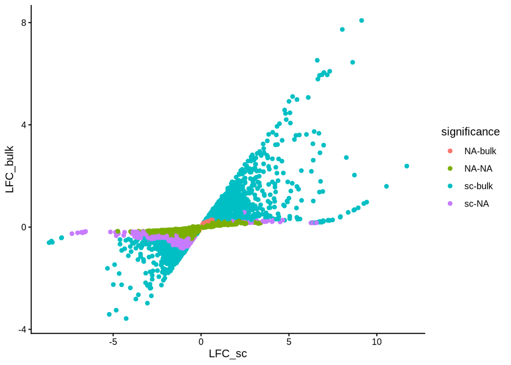

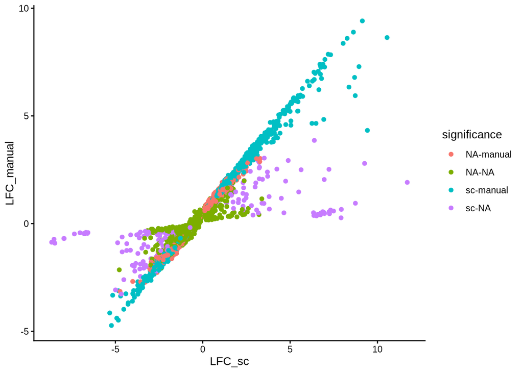

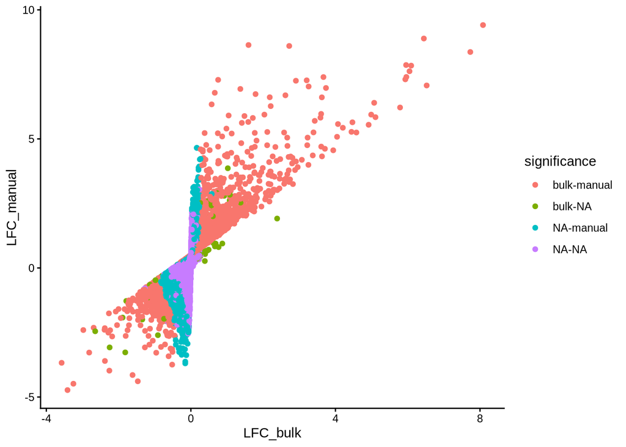

### pDC

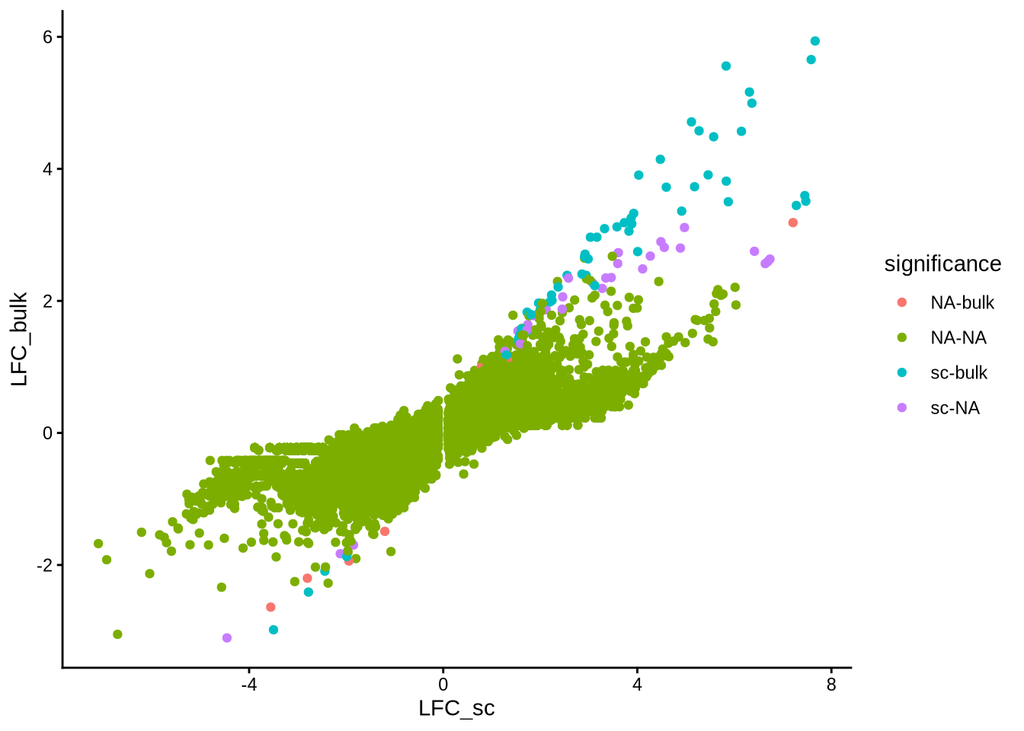

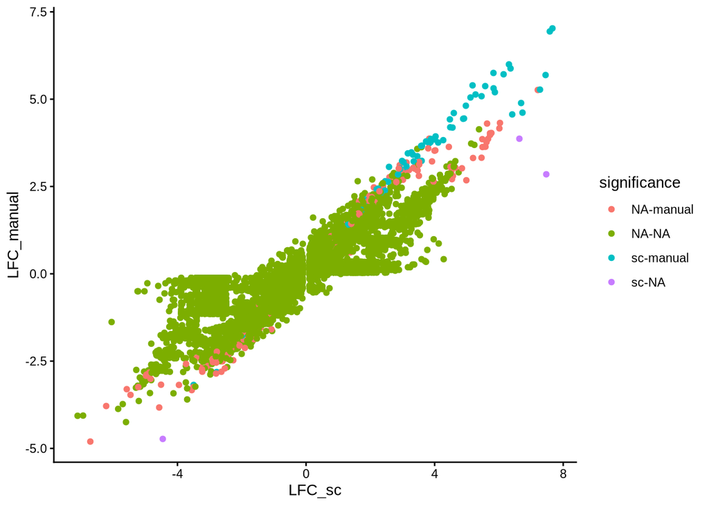

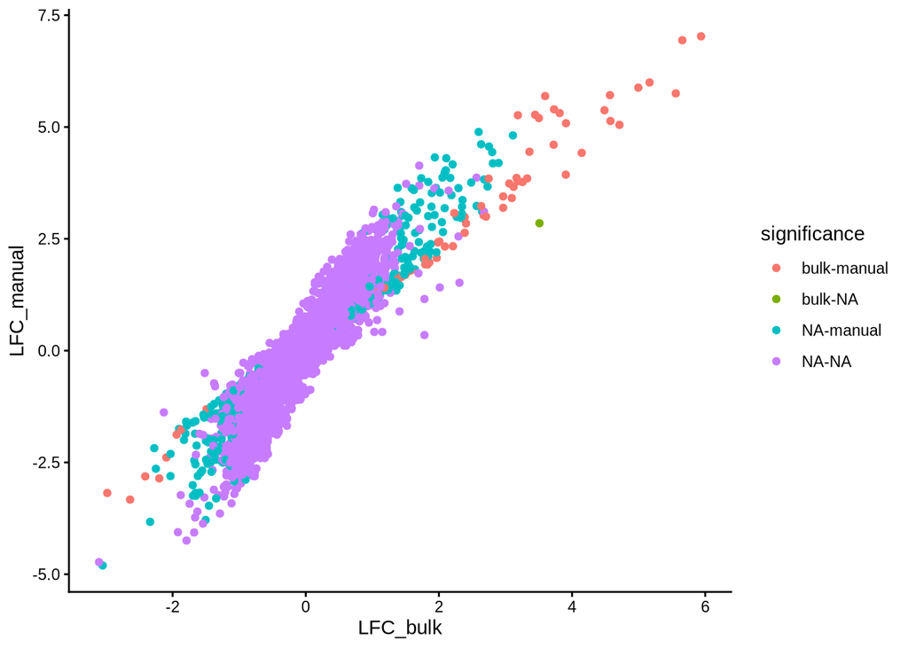

### CD4 Memory T

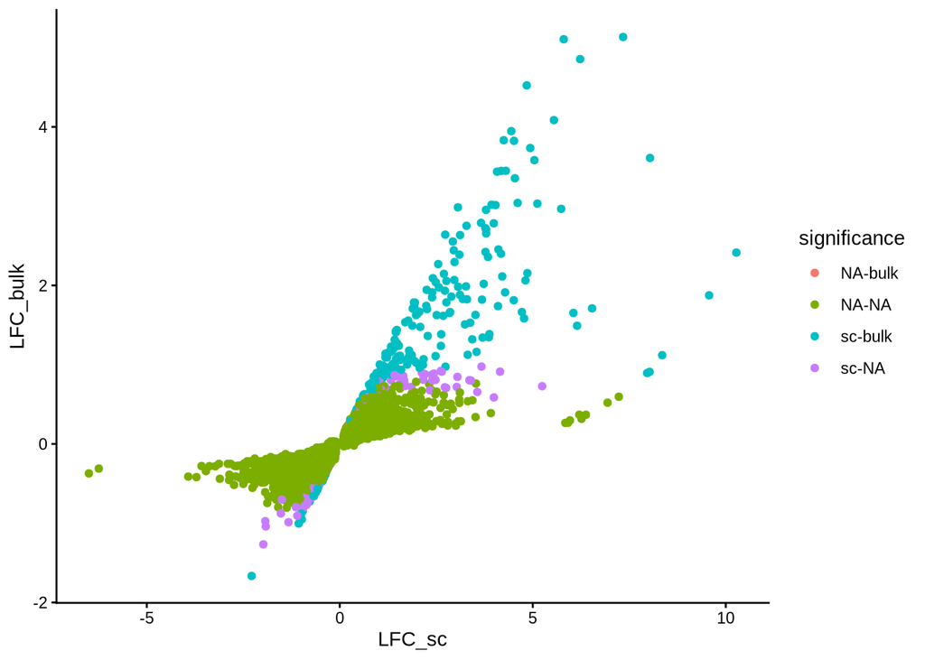

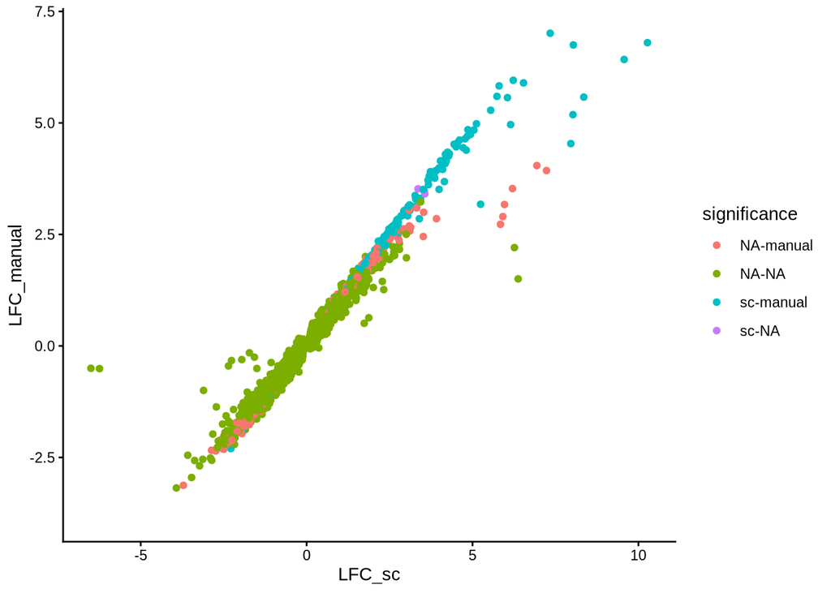

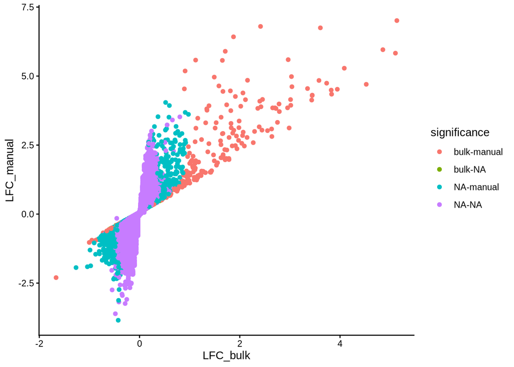

### T activated

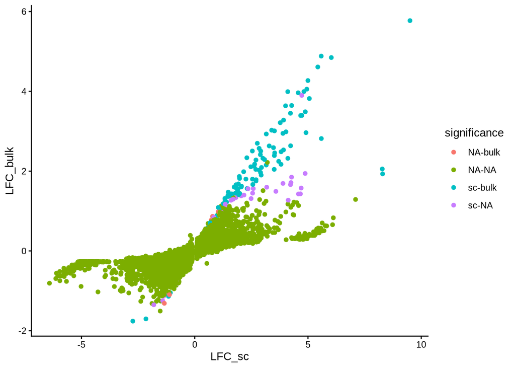

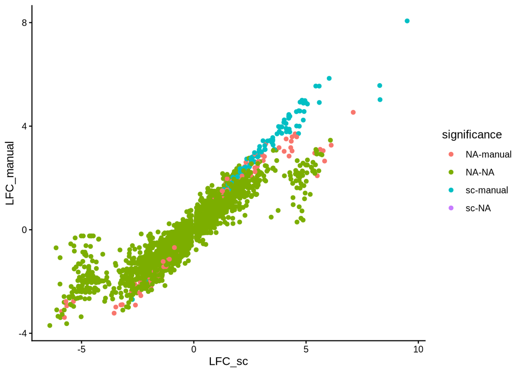

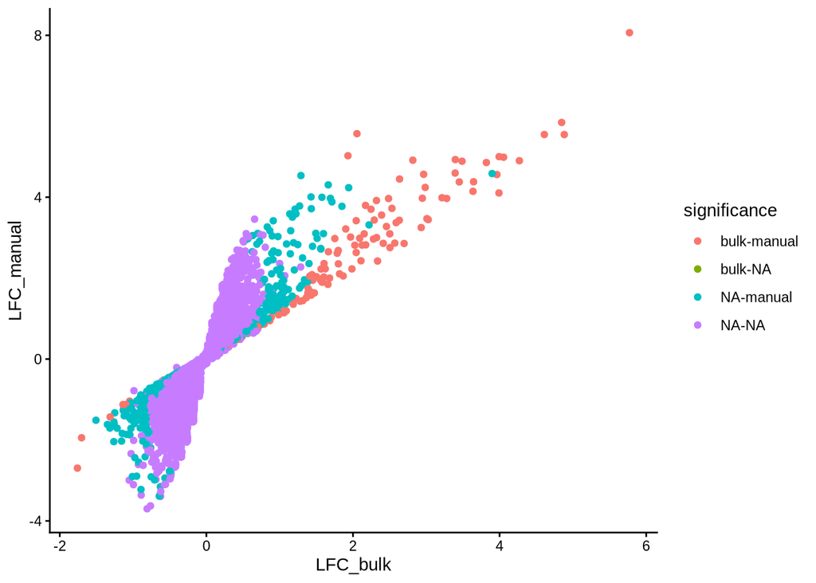

### CD4 Naive T

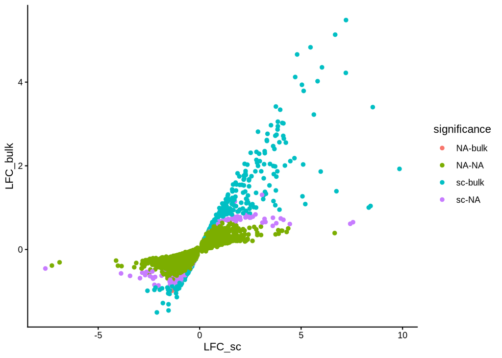

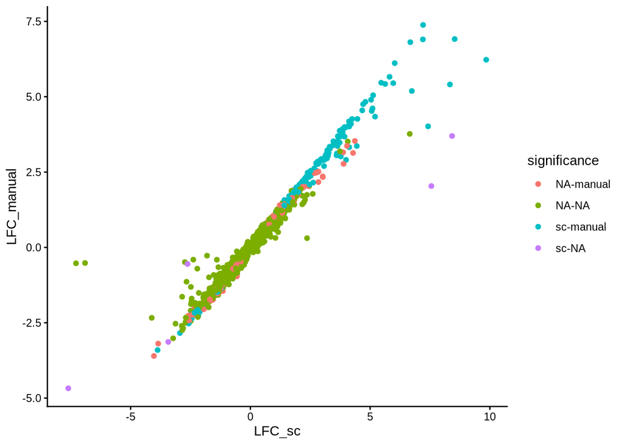

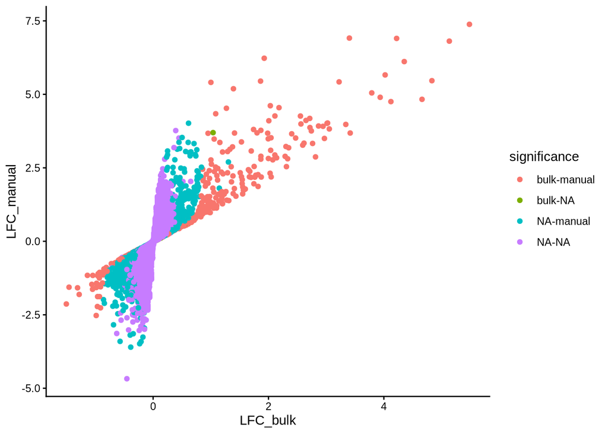

### CD8 T

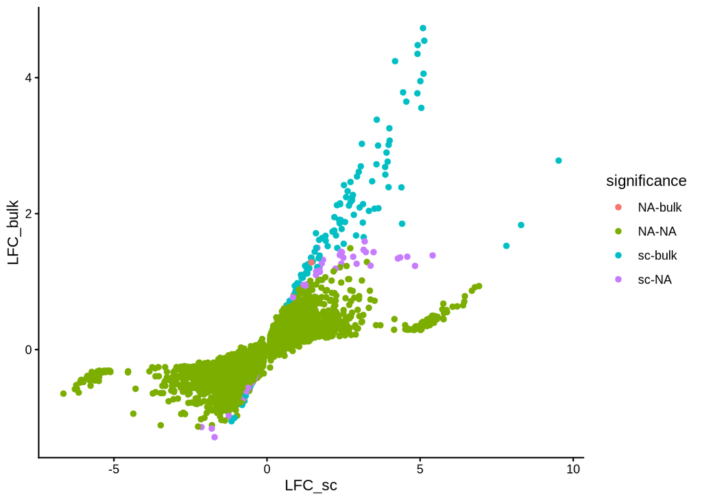

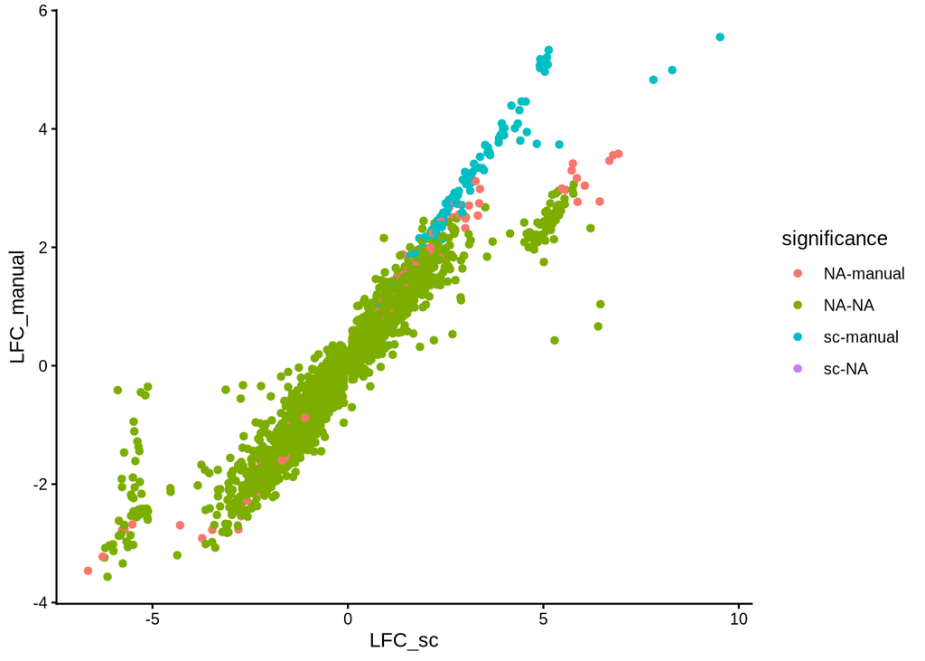

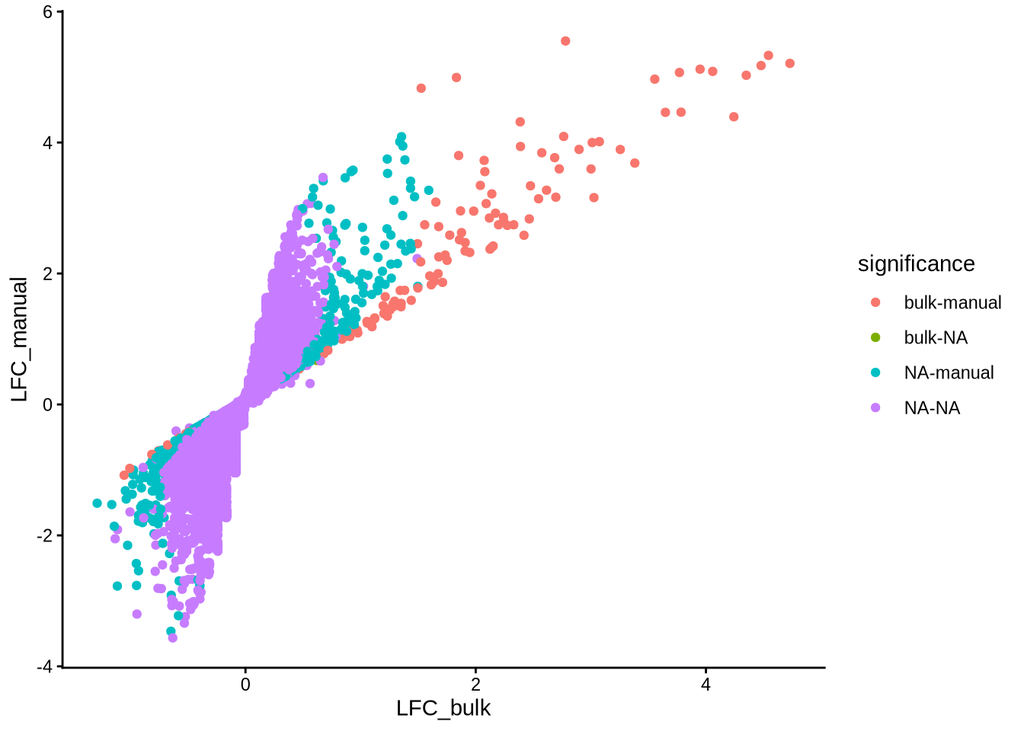

### Mk

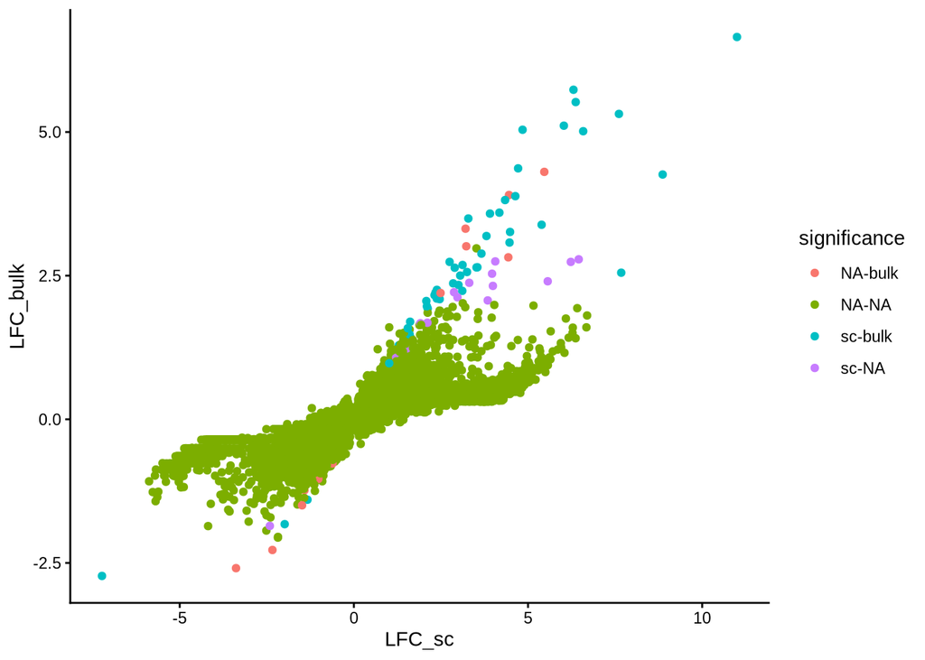

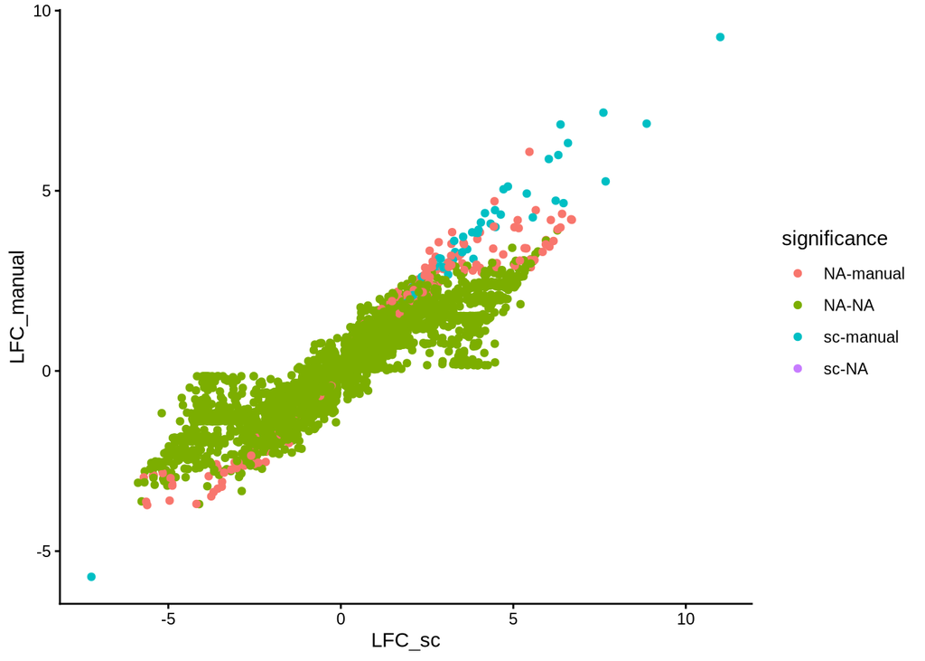

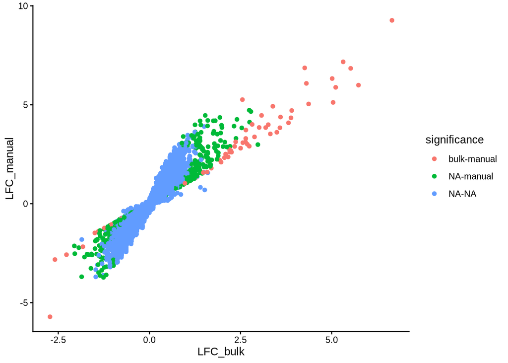

### B Activated

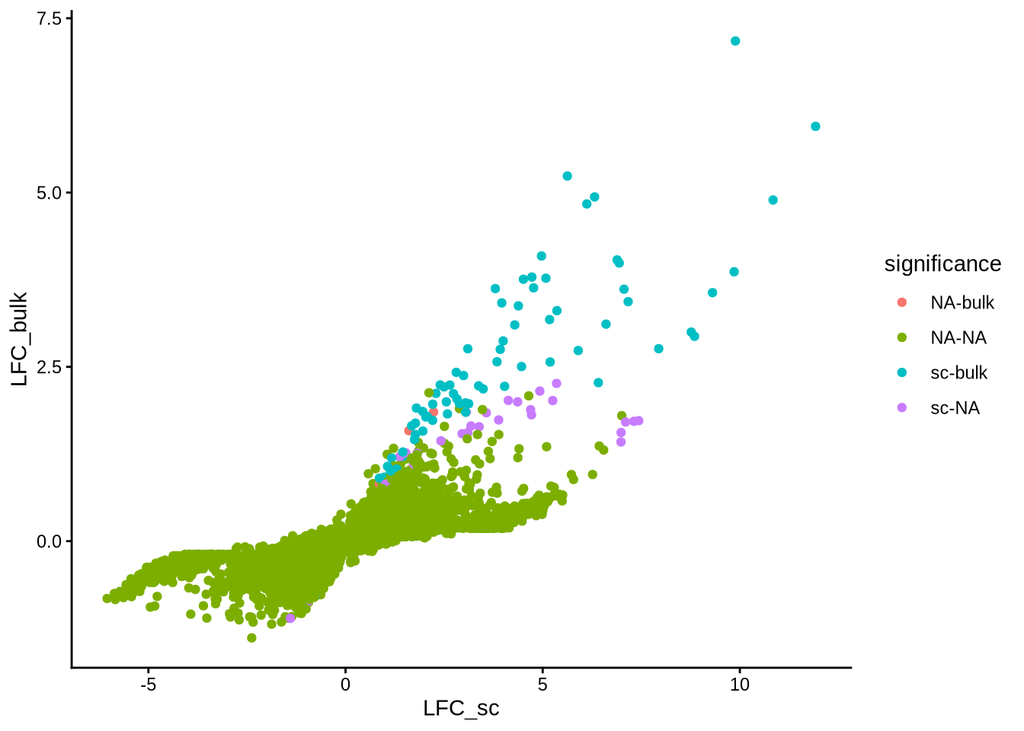

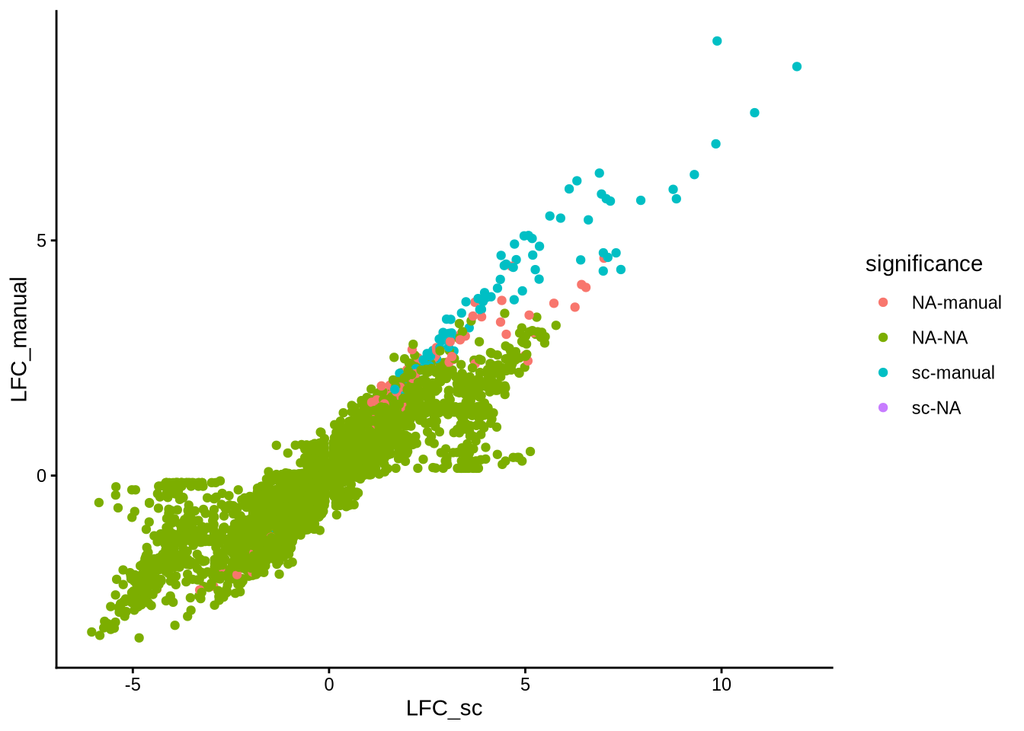

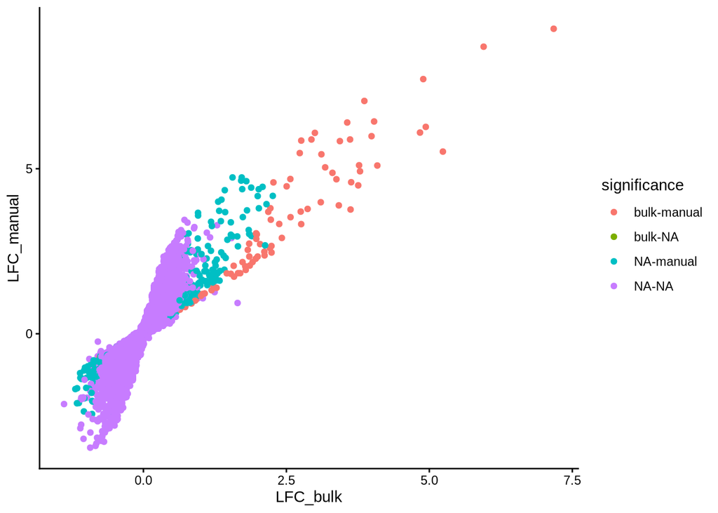

### B

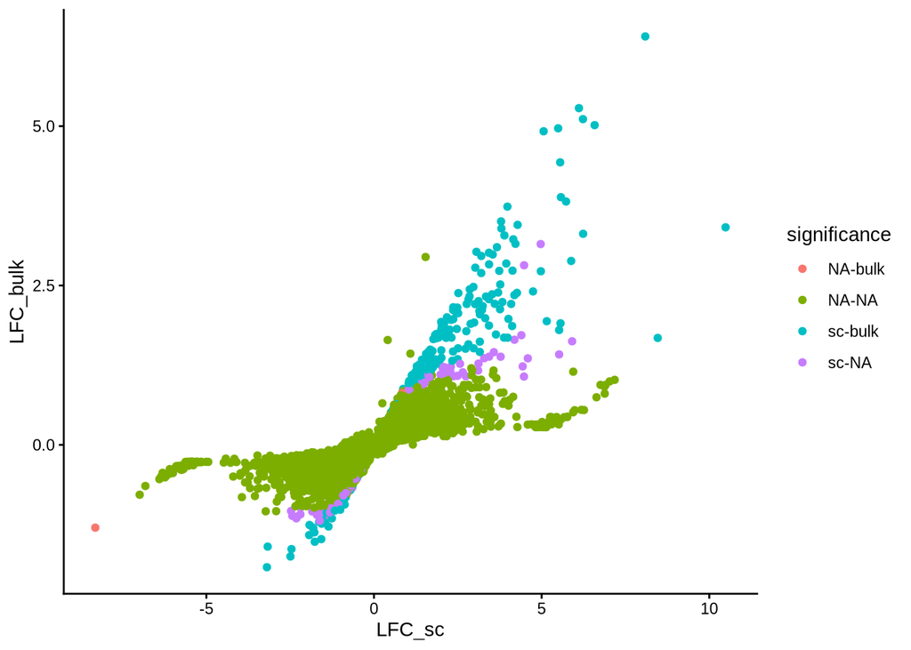

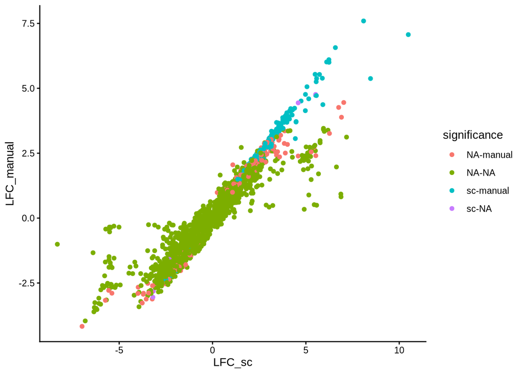

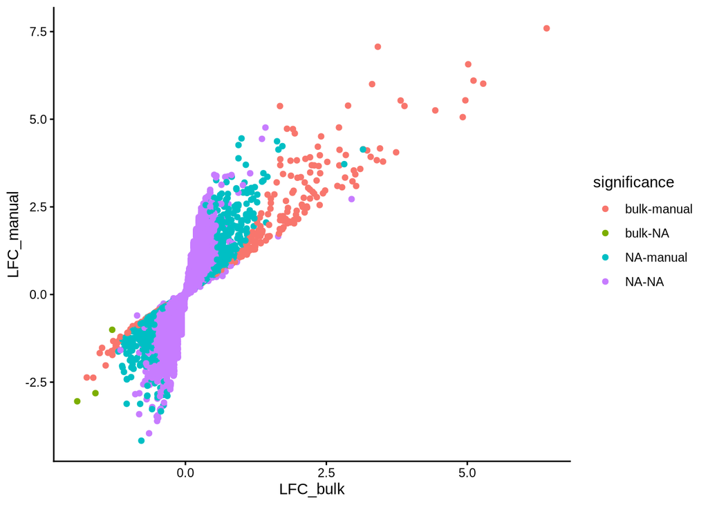

### DC

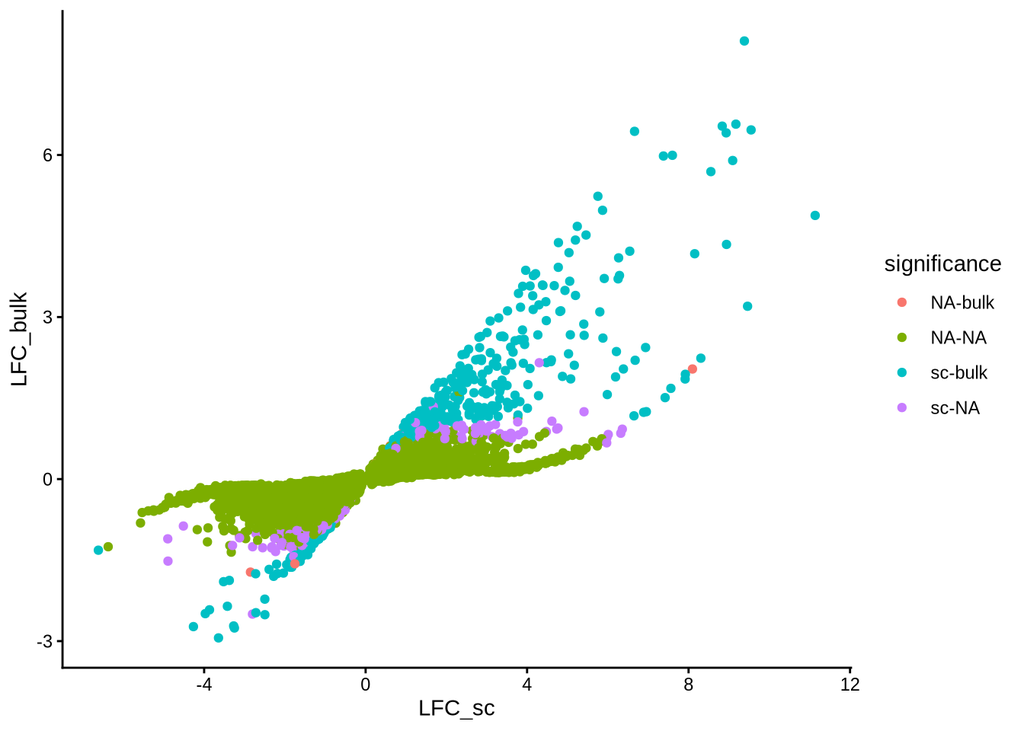

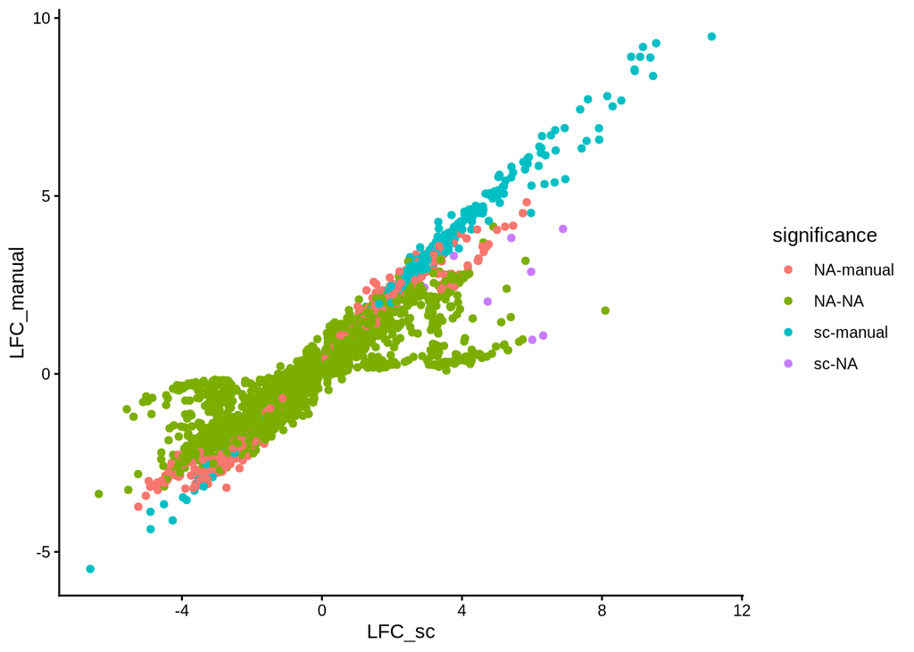

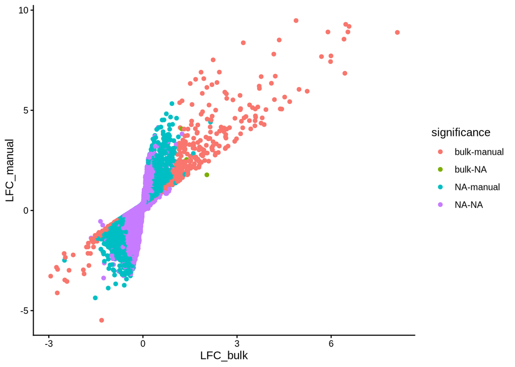